# GGW-mod2: Factor Analysis

# Setup

| EFA_correlation | CFA_coding | CFA_estimator |
| --- | --- | --- |
| cor | ordinal | WLSMV |

back to TOC

# Data preparation

back to TOC

# Data examination

back to TOC

# Study 1 (2015-12-15, 2 conditions, between-subjects)

## Demographics

Study 1: Exclusion

| did_not_finish | failed_catch_trial | did_not_provide_yob | too_young | TOTAL_excluded | TOTAL_participated | OVERALL_TOTAL |
| --- | --- | --- | --- | --- | --- | --- |
| 14 | 19 | 15 | 0 | 48 | 405 | 453 |

Study 1: Sample size

| condition | n |
| --- | --- |
| beetle | 200 |
| robot | 205 |
| all | 405 |

Study 1: Study duration (minutes)

| condition | min_duration | max_duration | median_duration | mean_duration | sd_duration |
| --- | --- | --- | --- | --- | --- |
| beetle | 0.77 | 119.12 | 2.77 | 3.92 | 8.50 |
| robot | 0.83 | 15.77 | 2.58 | 3.24 | 2.11 |
| all | 0.77 | 119.12 | 2.67 | 3.58 | 6.16 |

Study 1: Participant age (years; approximate)

| condition | min_age | max_age | median_age | mean_age | sd_age |
| --- | --- | --- | --- | --- | --- |
| beetle | 19 | 70 | 31 | 34.24 | 10.64 |
| robot | 20 | 75 | 32 | 35.11 | 11.20 |
| all | 19 | 75 | 32 | 34.68 | 10.92 |

Study 1: Participant gender

| condition | m | f | other |
| --- | --- | --- | --- |
| beetle | 119 | 81 | 0 |
| robot | 121 | 82 | 2 |
| all | 240 | 163 | 2 |

Study 1: Participant race/ethnicity

| condition | asian_east | asian_other | asian_south | black | hispanic | middle_eastern | multiracial | native_american | other_prefno | pac_islander | white |
| --- | --- | --- | --- | --- | --- | --- | --- | --- | --- | --- | --- |
| beetle | 20 | 0 | 6 | 8 | 9 | 1 | 11 | 1 | 1 | 1 | 142 |
| robot | 16 | 2 | 2 | 15 | 9 | 1 | 9 | 1 | 1 | 1 | 148 |
| all | 36 | 2 | 8 | 23 | 18 | 2 | 20 | 2 | 2 | 2 | 290 |

Study 1: Participant religion

| condition | buddhism | christianity | hinduism | islam | judaism | multireligious | none | other | other_prefno |
| --- | --- | --- | --- | --- | --- | --- | --- | --- | --- |
| beetle | 3 | 81 | 2 | 2 | 4 | 0 | 101 | 3 | 4 |
| robot | 2 | 87 | 0 | 0 | 5 | 3 | 100 | 3 | 5 |
| all | 5 | 168 | 2 | 2 | 9 | 3 | 201 | 6 | 9 |

back to TOC

## Exploratory factor analysis

### EFA: BEETLE condition

#### Step 1: Determine how many factors to extract

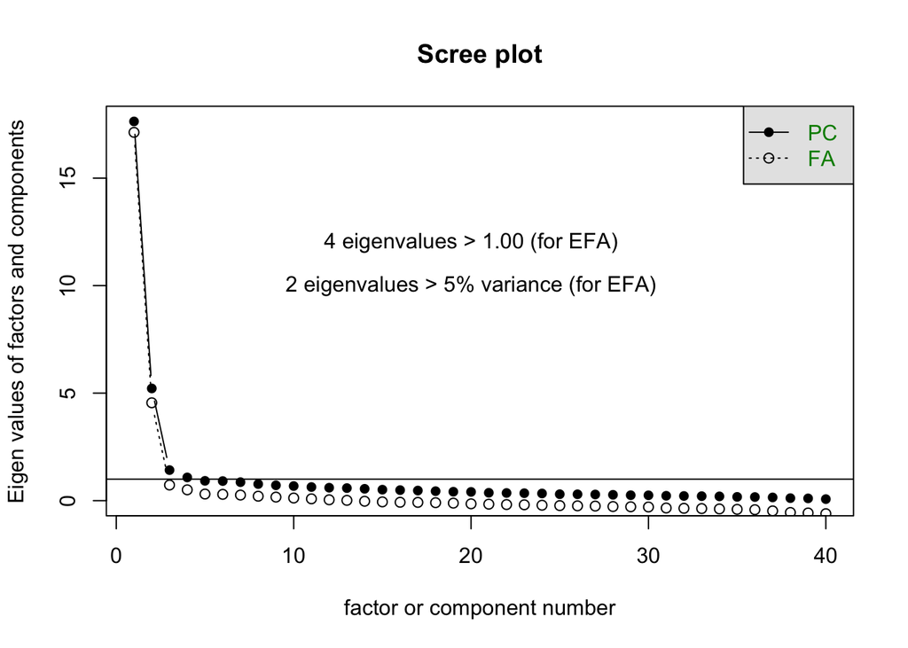

#### Step 2: Run EFA without rotation

```
## Factor Analysis using method =  minres
## Call: fa(r = d1_beetle, nfactors = 39, rotate = "none", fm = "minres",
##     cor = chosenCorType)
## Standardized loadings (pattern matrix) based upon correlation matrix
##                 MR1   MR2   MR7   MR5  MR12  MR15   MR9  MR16  MR10  MR13
## happy          0.80  0.50 -0.02 -0.03 -0.01  0.01  0.09  0.00 -0.15 -0.01
## depressed      0.88  0.02 -0.14  0.03 -0.01  0.01  0.05 -0.01  0.08  0.00
## fear           0.42  0.29  0.39  0.25  0.07 -0.40  0.27 -0.03  0.11  0.03
## angry          0.67  0.25  0.05  0.10  0.03 -0.17  0.15  0.00  0.07  0.03
## calm           0.56  0.32  0.26  0.19  0.12 -0.18  0.18  0.20  0.09 -0.03
## sounds         0.15  0.34  0.20  0.20  0.39  0.16  0.15 -0.10  0.07 -0.10
## seeing         0.07  0.33  0.37  0.21  0.40  0.21  0.19 -0.23  0.17 -0.08
## temperature    0.13  0.34  0.35  0.23  0.20  0.24  0.26 -0.12  0.17 -0.21
## odors          0.17  0.27  0.34  0.16  0.37  0.25  0.20  0.07  0.10 -0.05
## depth          0.30  0.31  0.29  0.24  0.19  0.19  0.05 -0.05  0.01 -0.08
## computations   0.62 -0.16 -0.01 -0.05 -0.04  0.10  0.04  0.04  0.12  0.09
## thoughts       0.69  0.27  0.11  0.18 -0.18  0.09  0.10 -0.01  0.15  0.37
## reasoning      0.76  0.13  0.10  0.07 -0.03  0.13  0.04  0.09  0.20  0.14
## remembering    0.43  0.26  0.26  0.26  0.07  0.25  0.14  0.20  0.12  0.05
## beliefs        0.80 -0.20 -0.04  0.00 -0.03  0.13 -0.04  0.00  0.08  0.03
## hungry         0.06  0.39  0.41  0.22  0.21  0.11  0.25 -0.07  0.12 -0.18
## tired          0.39  0.38  0.30  0.22  0.02 -0.08  0.19 -0.05  0.21 -0.08
## pain           0.23  0.37  0.46  0.22  0.22 -0.17  0.30 -0.23  0.25 -0.04
## nauseated      0.67  0.25  0.14  0.24  0.17 -0.15  0.03  0.20  0.11  0.00
## safe           0.48  0.35  0.24  0.19  0.12 -0.14  0.10  0.25  0.10  0.00
## love           0.88  0.14  0.07 -0.32  0.00  0.00  0.03  0.00 -0.08  0.00
## recognizing    0.63  0.15  0.11  0.24  0.18  0.17 -0.02  0.27  0.08  0.15
## communicating  0.41  0.13  0.35  0.24  0.25  0.20  0.06  0.03  0.01  0.14
## guilt          0.86 -0.22  0.01 -0.07  0.01  0.00 -0.06  0.01  0.03 -0.01
## disrespected   0.85 -0.26  0.08  0.09  0.00  0.00 -0.09  0.00 -0.11 -0.01
## free_will      0.47  0.31  0.25  0.12 -0.14 -0.03  0.13  0.16  0.05 -0.09
## choices        0.41  0.33  0.41  0.23 -0.21  0.16  0.21  0.21  0.11 -0.16
## self_restraint 0.72  0.06  0.25  0.12 -0.02 -0.04 -0.08 -0.13 -0.13  0.29
## intentions     0.47  0.34  0.33  0.31 -0.42 -0.03  0.05 -0.05  0.14 -0.22
## goal           0.40  0.28  0.32  0.31 -0.22  0.20 -0.03 -0.25  0.20 -0.09
## conscious      0.52  0.26  0.32  0.18  0.05  0.07  0.13  0.00  0.08  0.03
## self_aware     0.59  0.22  0.21  0.15 -0.11 -0.04  0.09 -0.05  0.06  0.18
## desires        0.53  0.26  0.32  0.26 -0.14 -0.12  0.05  0.11  0.06 -0.05
## embarrassed    0.86 -0.35  0.07 -0.17  0.00  0.00  0.09  0.00  0.13  0.02
## emo_recog      0.86 -0.21  0.09  0.17  0.01  0.00 -0.10  0.00 -0.10 -0.01
```

[output cut: 231 more lines]

```
## Correlation of scores with factors             0.82 0.75 0.72 0.74  0.71
## Multiple R square of scores with factors       0.68 0.57 0.52 0.55  0.50
## Minimum correlation of possible factor scores  0.35 0.13 0.03 0.11 -0.01
##                                                 MR32  MR31  MR33  MR35
## Correlation of scores with factors              0.66  0.68  0.62  0.59
## Multiple R square of scores with factors        0.43  0.47  0.38  0.35
## Minimum correlation of possible factor scores  -0.13 -0.06 -0.23 -0.31
##                                                 MR34  MR37  MR36  MR38
## Correlation of scores with factors              0.59  0.49  0.54  0.42
## Multiple R square of scores with factors        0.35  0.24  0.29  0.18
## Minimum correlation of possible factor scores  -0.30 -0.53 -0.41 -0.65
##                                                 MR39
## Correlation of scores with factors              0.21
## Multiple R square of scores with factors        0.04
## Minimum correlation of possible factor scores  -0.91
```

#### Step 3: Run EFA with oblimin rotation

```
## Factor Analysis using method =  minres
## Call: fa(r = d1_beetle, nfactors = nfactors_d1_beetle, rotate = "oblimin",
##     fm = "minres", cor = chosenCorType)
## Standardized loadings (pattern matrix) based upon correlation matrix
##                  MR1   MR2   h2   u2 com
## happy           0.60  0.35 0.65 0.35 1.6
## depressed       0.82  0.08 0.73 0.27 1.0
## fear            0.15  0.64 0.50 0.50 1.1
## angry           0.50  0.36 0.53 0.47 1.8
## calm            0.30  0.59 0.58 0.42 1.5
## sounds         -0.13  0.59 0.30 0.70 1.1
## seeing         -0.26  0.70 0.41 0.59 1.3
## temperature    -0.21  0.72 0.44 0.56 1.2
## odors          -0.12  0.63 0.35 0.65 1.1
## depth           0.05  0.54 0.32 0.68 1.0
## computations    0.69 -0.11 0.43 0.57 1.0
## thoughts        0.53  0.39 0.60 0.40 1.8
## reasoning       0.67  0.25 0.64 0.36 1.3
## remembering     0.20  0.55 0.43 0.57 1.3
## beliefs         0.87 -0.12 0.69 0.31 1.0
## hungry         -0.30  0.78 0.51 0.49 1.3
## tired           0.07  0.70 0.53 0.47 1.0
## pain           -0.13  0.79 0.56 0.44 1.1
## nauseated       0.46  0.45 0.59 0.41 2.0
## safe            0.22  0.56 0.46 0.54 1.3
## love            0.80  0.11 0.72 0.28 1.0
## recognizing     0.48  0.35 0.49 0.51 1.8
## communicating   0.21  0.46 0.33 0.67 1.4
## guilt           0.89 -0.09 0.74 0.26 1.0
## disrespected    0.86 -0.04 0.71 0.29 1.0
## free_will       0.24  0.51 0.42 0.58 1.4
## choices         0.12  0.66 0.51 0.49 1.1
## self_restraint  0.63  0.23 0.56 0.44 1.3
## intentions      0.20  0.59 0.49 0.51 1.2
## goal            0.14  0.57 0.41 0.59 1.1
## conscious       0.29  0.53 0.49 0.51 1.5
## self_aware      0.42  0.42 0.49 0.51 2.0
## desires         0.31  0.51 0.48 0.52 1.7
## embarrassed     0.94 -0.20 0.78 0.22 1.1
## emo_recog       0.88 -0.05 0.74 0.26 1.0
```

[output cut: 24 more lines]

```
## The root mean square of the residuals (RMSR) is  0.04
## The df corrected root mean square of the residuals is  0.04
##
## The harmonic number of observations is  200 with the empirical chi square  565.19  with prob <  1
## The total number of observations was  200  with MLE Chi Square =  1185.72  with prob <  1.7e-27
##
## Tucker Lewis Index of factoring reliability =  0.901
## RMSEA index =  0.065  and the 90 % confidence intervals are  0.053 NA
## BIC =  -2528.4
## Fit based upon off diagonal values = 0.99
## Measures of factor score adequacy
##                                                 MR1  MR2
## Correlation of scores with factors             0.99 0.97
## Multiple R square of scores with factors       0.97 0.95
## Minimum correlation of possible factor scores  0.95 0.89
```

back to TOC

##### Factor 1

Study 1, BEETLE condition: Rotated Factor 1

|  | F1 |
| --- | --- |
| embarrassed | 0.9440523 |
| pride | 0.9081533 |
| guilt | 0.8906603 |
| emo_recog | 0.8782222 |
| beliefs | 0.8736313 |
| disrespected | 0.8566385 |
| depressed | 0.8240501 |
| love | 0.7994946 |
| morality | 0.7811438 |
| personality | 0.7089780 |
| computations | 0.6939023 |
| joy | 0.6695277 |
| reasoning | 0.6652942 |
| self_restraint | 0.6305370 |
| happy | 0.6034206 |
| thoughts | 0.5276238 |
| angry | 0.5021990 |
| recognizing | 0.4820272 |
| nauseated | 0.4634142 |
| self_aware | 0.4178148 |
| desires | 0.3107010 |
| calm | 0.3036958 |
| conscious | 0.2902389 |
| pleasure | 0.2676393 |
| free_will | 0.2449147 |
| safe | 0.2222686 |
| communicating | 0.2085438 |
| remembering | 0.2045590 |
| intentions | 0.2038521 |
| fear | 0.1453854 |
| goal | 0.1418002 |
| choices | 0.1187407 |
| tired | 0.0685213 |
| depth | 0.0458845 |
| odors | -0.1191542 |
| sounds | -0.1290391 |
| pain | -0.1312234 |
| temperature | -0.2136876 |
| seeing | -0.2571438 |
| hungry | -0.3005762 |

##### Factor 2

Study 1, BEETLE condition: Rotated Factor 2

|  | F2 |
| --- | --- |
| pain | 0.7926481 |
| hungry | 0.7752471 |
| temperature | 0.7170307 |
| tired | 0.6977625 |
| seeing | 0.6959057 |
| choices | 0.6580347 |
| fear | 0.6351036 |
| pleasure | 0.6283244 |
| odors | 0.6270289 |
| intentions | 0.5942473 |
| calm | 0.5879397 |
| sounds | 0.5857267 |
| goal | 0.5745682 |
| safe | 0.5627134 |
| remembering | 0.5500451 |
| depth | 0.5422707 |
| conscious | 0.5307070 |
| free_will | 0.5100530 |
| desires | 0.5099156 |
| communicating | 0.4623823 |
| nauseated | 0.4546992 |
| self_aware | 0.4206549 |
| thoughts | 0.3919741 |
| angry | 0.3616163 |
| recognizing | 0.3510067 |
| happy | 0.3465516 |
| joy | 0.2979975 |
| reasoning | 0.2510172 |
| self_restraint | 0.2287306 |
| personality | 0.1776459 |
| love | 0.1145687 |
| depressed | 0.0758815 |
| morality | -0.0097803 |
| pride | -0.0281165 |
| disrespected | -0.0391258 |
| emo_recog | -0.0511680 |
| guilt | -0.0851762 |
| computations | -0.1070958 |
| beliefs | -0.1245751 |
| embarrassed | -0.2021787 |

##### Factor 3 (*not applicable*)

back to TOC

### EFA: ROBOT condition

#### Step 1: Determine how many factors to extract

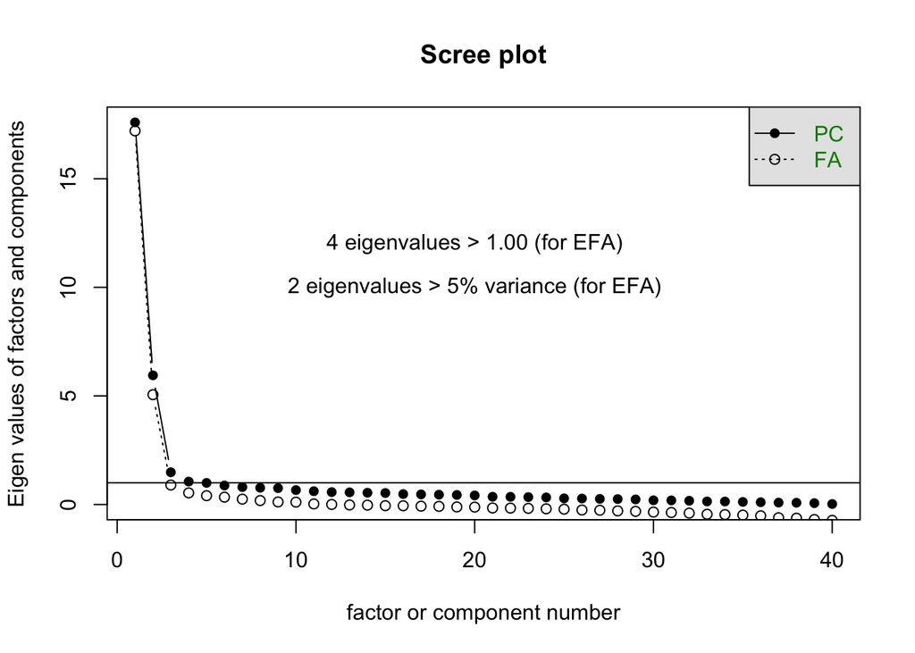

#### Step 2: Run EFA without rotation

[output not shown]

[output cut: 231 more lines]

[output not shown]

#### Step 3: Run EFA with oblimin rotation

```
## Factor Analysis using method =  minres
## Call: fa(r = d1_robot, nfactors = nfactors_d1_robot, rotate = "oblimin",
##     fm = "minres", cor = chosenCorType)
## Standardized loadings (pattern matrix) based upon correlation matrix
##                  MR1   MR2   h2   u2 com
## happy           0.89 -0.02 0.78 0.22 1.0
## depressed       0.89 -0.11 0.76 0.24 1.0
## fear            0.92 -0.02 0.84 0.16 1.0
## angry           0.88 -0.01 0.77 0.23 1.0
## calm            0.61  0.13 0.42 0.58 1.1
## sounds         -0.15  0.64 0.39 0.61 1.1
## seeing         -0.02  0.73 0.53 0.47 1.0
## temperature    -0.09  0.71 0.48 0.52 1.0
## odors           0.01  0.54 0.29 0.71 1.0
## depth           0.04  0.64 0.42 0.58 1.0
## computations   -0.22  0.58 0.33 0.67 1.3
## thoughts        0.57  0.26 0.46 0.54 1.4
## reasoning       0.21  0.62 0.48 0.52 1.2
## remembering    -0.04  0.70 0.49 0.51 1.0
## beliefs         0.70  0.13 0.54 0.46 1.1
## hungry          0.70  0.02 0.49 0.51 1.0
## tired           0.76  0.09 0.62 0.38 1.0
## pain            0.81  0.01 0.65 0.35 1.0
## nauseated       0.86 -0.13 0.71 0.29 1.0
## safe            0.74  0.08 0.57 0.43 1.0
## love            0.95 -0.06 0.88 0.12 1.0
## recognizing    -0.04  0.79 0.62 0.38 1.0
## communicating   0.04  0.66 0.45 0.55 1.0
## guilt           0.81 -0.04 0.65 0.35 1.0
## disrespected    0.79 -0.04 0.61 0.39 1.0
## free_will       0.75  0.09 0.60 0.40 1.0
## choices         0.07  0.64 0.44 0.56 1.0
## self_restraint  0.39  0.36 0.34 0.66 2.0
## intentions      0.46  0.28 0.35 0.65 1.7
## goal            0.01  0.64 0.41 0.59 1.0
## conscious       0.66  0.09 0.47 0.53 1.0
## self_aware      0.59  0.23 0.46 0.54 1.3
## desires         0.75  0.08 0.59 0.41 1.0
## embarrassed     0.96 -0.10 0.90 0.10 1.0
## emo_recog       0.52  0.37 0.49 0.51 1.8
```

[output cut: 24 more lines]

```
## The root mean square of the residuals (RMSR) is  0.05
## The df corrected root mean square of the residuals is  0.05
##
## The harmonic number of observations is  205 with the empirical chi square  717.63  with prob <  0.32
## The total number of observations was  205  with MLE Chi Square =  1667.76  with prob <  1.6e-80
##
## Tucker Lewis Index of factoring reliability =  0.836
## RMSEA index =  0.088  and the 90 % confidence intervals are  0.077 NA
## BIC =  -2063.67
## Fit based upon off diagonal values = 0.99
## Measures of factor score adequacy
##                                                 MR1  MR2
## Correlation of scores with factors             1.00 0.97
## Multiple R square of scores with factors       0.99 0.94
## Minimum correlation of possible factor scores  0.98 0.87
```

back to TOC

##### Factor 1

Study 1, ROBOT condition: Rotated Factor 1

|  | F1 |
| --- | --- |
| embarrassed | 0.9641037 |
| pleasure | 0.9472343 |
| love | 0.9468109 |
| fear | 0.9186321 |
| pride | 0.8961650 |
| happy | 0.8884707 |
| depressed | 0.8861983 |
| angry | 0.8801143 |
| joy | 0.8722513 |
| nauseated | 0.8587571 |
| guilt | 0.8137563 |
| pain | 0.8070472 |
| disrespected | 0.7866940 |
| tired | 0.7636259 |
| free_will | 0.7528521 |
| desires | 0.7489788 |
| safe | 0.7358679 |
| hungry | 0.6985322 |
| beliefs | 0.6973072 |
| conscious | 0.6566758 |
| calm | 0.6100252 |
| self_aware | 0.5905387 |
| thoughts | 0.5728410 |
| personality | 0.5299597 |
| emo_recog | 0.5173974 |
| intentions | 0.4623337 |
| morality | 0.4430973 |
| self_restraint | 0.3930128 |
| reasoning | 0.2074653 |
| choices | 0.0715817 |
| depth | 0.0418538 |
| communicating | 0.0404534 |
| goal | 0.0129035 |
| odors | 0.0087600 |
| seeing | -0.0222526 |
| remembering | -0.0392736 |
| recognizing | -0.0431046 |
| temperature | -0.0895492 |
| sounds | -0.1470091 |
| computations | -0.2151674 |

##### Factor 2

Study 1, ROBOT condition: Rotated Factor 2

|  | F2 |
| --- | --- |
| recognizing | 0.7937630 |
| seeing | 0.7316885 |
| temperature | 0.7069351 |
| remembering | 0.7047323 |
| communicating | 0.6634524 |
| choices | 0.6449227 |
| sounds | 0.6426030 |
| goal | 0.6389682 |
| depth | 0.6377965 |
| reasoning | 0.6208181 |
| computations | 0.5765235 |
| odors | 0.5351102 |
| personality | 0.3922183 |
| morality | 0.3720688 |
| emo_recog | 0.3695686 |
| self_restraint | 0.3567544 |
| intentions | 0.2826026 |
| thoughts | 0.2590255 |
| self_aware | 0.2300412 |
| beliefs | 0.1344118 |
| calm | 0.1272897 |
| conscious | 0.0910407 |
| tired | 0.0874804 |
| free_will | 0.0860418 |
| safe | 0.0814668 |
| desires | 0.0813625 |
| hungry | 0.0159091 |
| pain | 0.0088341 |
| angry | -0.0103937 |
| joy | -0.0181458 |
| fear | -0.0223205 |
| happy | -0.0223783 |
| pride | -0.0321841 |
| guilt | -0.0404905 |
| disrespected | -0.0406588 |
| pleasure | -0.0575347 |
| love | -0.0579180 |
| embarrassed | -0.1023760 |
| depressed | -0.1136898 |
| nauseated | -0.1340358 |

##### Factor 3 (*not applicable*)

back to TOC

### EFA: ALL conditions

#### Step 1: Determine how many factors to extract

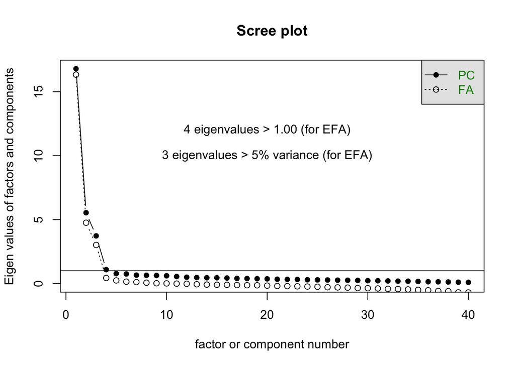

#### Step 2: Run EFA without rotation

```
## Factor Analysis using method =  minres
## Call: fa(r = d1_all, nfactors = 39, rotate = "none", fm = "minres",
##     cor = chosenCorType)
## Standardized loadings (pattern matrix) based upon correlation matrix
##                  MR1   MR2   MR4   MR6   MR3  MR10   MR7  MR11  MR12   MR8
## happy           0.89  0.22 -0.06 -0.02  0.28  0.00 -0.03 -0.01  0.00  0.00
## depressed       0.77  0.36  0.01 -0.01 -0.03 -0.19  0.11 -0.06  0.04  0.20
## fear            0.80 -0.28  0.13 -0.02 -0.07  0.06  0.10  0.25 -0.14 -0.02
## angry           0.80  0.09  0.09  0.00  0.02 -0.07  0.14  0.04 -0.03  0.09
## calm            0.75 -0.06  0.15  0.08  0.05  0.07  0.11  0.11 -0.09  0.08
## sounds          0.06  0.01  0.44  0.33  0.19 -0.11 -0.23  0.19  0.15  0.00
## seeing          0.28 -0.21  0.49  0.31  0.07 -0.02 -0.25  0.09  0.30 -0.04
## temperature     0.17 -0.09  0.51  0.39  0.10 -0.07 -0.19  0.18  0.16 -0.06
## odors           0.37 -0.23  0.29  0.30  0.07 -0.02 -0.14  0.10  0.22  0.02
## depth           0.19  0.10  0.44  0.34  0.13 -0.03 -0.11  0.03  0.15 -0.07
## computations   -0.44  0.67  0.40  0.19  0.09 -0.20 -0.10 -0.04 -0.24 -0.02
## thoughts        0.73  0.12  0.19  0.06  0.10  0.22  0.07 -0.15 -0.07  0.05
## reasoning       0.27  0.45  0.42  0.27  0.06  0.25 -0.15 -0.15  0.01 -0.03
## remembering    -0.01  0.34  0.54  0.36  0.16  0.03 -0.14  0.05  0.01 -0.06
## beliefs         0.54  0.49  0.07  0.12 -0.19  0.13  0.02 -0.22 -0.04  0.07
## hungry          0.74 -0.62 -0.15  0.18 -0.09 -0.02 -0.03 -0.01 -0.02  0.01
## tired           0.79 -0.33  0.10  0.10 -0.01 -0.06  0.10  0.13  0.01 -0.03
## pain            0.80 -0.53  0.18 -0.17 -0.12 -0.01 -0.05 -0.02  0.00  0.01
## nauseated       0.81  0.00  0.08  0.02  0.04 -0.17  0.11  0.09  0.00  0.03
## safe            0.77 -0.12  0.09  0.06  0.05  0.14  0.10  0.26 -0.12 -0.01
## love            0.79  0.41  0.02 -0.01 -0.03  0.02  0.11  0.08  0.03  0.30
## recognizing    -0.01  0.47  0.53  0.38  0.17  0.01 -0.11 -0.02  0.20  0.01
## communicating   0.13  0.22  0.52  0.33  0.07  0.07 -0.11  0.00  0.09  0.01
## guilt           0.68  0.41 -0.02  0.05 -0.12 -0.06  0.02 -0.16 -0.05  0.23
## disrespected    0.66  0.42  0.03  0.09 -0.24 -0.15  0.16 -0.03  0.06  0.22
## free_will       0.76 -0.14  0.08  0.06  0.04  0.19  0.13  0.06 -0.11  0.08
## choices         0.32  0.05  0.45  0.35  0.10  0.26 -0.03  0.00  0.03 -0.03
## self_restraint  0.51  0.27  0.21  0.19  0.06  0.21  0.03 -0.11 -0.09  0.19
## intentions      0.62 -0.03  0.21  0.16  0.08  0.21  0.11  0.03 -0.12  0.00
## goal            0.19  0.15  0.47  0.37  0.13  0.07  0.01 -0.01  0.11 -0.06
## conscious       0.76 -0.15  0.14  0.00  0.01  0.11  0.05 -0.05 -0.01  0.04
## self_aware      0.70  0.06  0.20  0.08  0.05  0.11  0.10 -0.14 -0.04  0.05
## desires         0.77 -0.11  0.12  0.06  0.02  0.16  0.19 -0.04 -0.10 -0.02
## embarrassed     0.69  0.57 -0.04  0.00 -0.44  0.01 -0.04  0.01  0.00 -0.05
## emo_recog       0.47  0.50  0.20  0.19 -0.13  0.20  0.00 -0.16  0.02  0.09
```

[output cut: 231 more lines]

```
## Correlation of scores with factors              0.65  0.68  0.65  0.61
## Multiple R square of scores with factors        0.42  0.47  0.42  0.37
## Minimum correlation of possible factor scores  -0.15 -0.06 -0.16 -0.26
##                                                 MR30  MR31  MR32  MR33
## Correlation of scores with factors              0.57  0.54  0.53  0.49
## Multiple R square of scores with factors        0.33  0.29  0.28  0.24
## Minimum correlation of possible factor scores  -0.35 -0.42 -0.44 -0.52
##                                                 MR34  MR35  MR36  MR37
## Correlation of scores with factors              0.44  0.39  0.36  0.35
## Multiple R square of scores with factors        0.19  0.16  0.13  0.12
## Minimum correlation of possible factor scores  -0.62 -0.69 -0.74 -0.76
##                                                 MR38  MR39
## Correlation of scores with factors              0.28  0.17
## Multiple R square of scores with factors        0.08  0.03
## Minimum correlation of possible factor scores  -0.85 -0.94
```

#### Step 3: Run EFA with oblimin rotation

```
## Factor Analysis using method =  minres
## Call: fa(r = d1_all, nfactors = nfactors_d1_all, rotate = "oblimin",
##     fm = "minres", cor = chosenCorType)
## Standardized loadings (pattern matrix) based upon correlation matrix
##                  MR1   MR2   MR3   h2   u2 com
## happy           0.64  0.37  0.04 0.74 0.26 1.6
## depressed       0.82  0.15 -0.06 0.75 0.25 1.1
## fear            0.20  0.77  0.05 0.76 0.24 1.2
## angry           0.55  0.43  0.03 0.67 0.33 1.9
## calm            0.35  0.55  0.15 0.62 0.38 1.9
## sounds         -0.18  0.07  0.64 0.38 0.62 1.2
## seeing         -0.25  0.39  0.66 0.51 0.49 2.0
## temperature    -0.23  0.23  0.70 0.48 0.52 1.4
## odors          -0.15  0.47  0.47 0.39 0.61 2.2
## depth          -0.02  0.07  0.63 0.40 0.60 1.0
## computations    0.21 -0.83  0.41 0.78 0.22 1.6
## thoughts        0.51  0.35  0.18 0.61 0.39 2.1
## reasoning       0.41 -0.21  0.53 0.55 0.45 2.2
## remembering     0.06 -0.26  0.73 0.59 0.41 1.3
## beliefs         0.80 -0.12  0.03 0.60 0.40 1.0
## hungry         -0.08  0.96 -0.06 0.87 0.13 1.0
## tired           0.15  0.79  0.10 0.76 0.24 1.1
## pain            0.01  0.93  0.02 0.87 0.13 1.0
## nauseated       0.46  0.52  0.05 0.68 0.32 2.0
## safe            0.30  0.61  0.11 0.63 0.37 1.5
## love            0.84  0.13 -0.03 0.79 0.21 1.1
## recognizing     0.21 -0.39  0.69 0.67 0.33 1.8
## communicating   0.08 -0.09  0.65 0.46 0.54 1.1
## guilt           0.85  0.03 -0.08 0.70 0.30 1.0
## disrespected    0.83  0.03 -0.05 0.68 0.32 1.0
## free_will       0.31  0.61  0.07 0.63 0.37 1.5
## choices         0.05  0.20  0.62 0.46 0.54 1.2
## self_restraint  0.51  0.08  0.26 0.45 0.55 1.5
## intentions      0.27  0.45  0.25 0.48 0.52 2.3
## goal            0.04  0.04  0.63 0.42 0.58 1.0
## conscious       0.30  0.62  0.11 0.64 0.36 1.5
## self_aware      0.43  0.39  0.18 0.55 0.45 2.3
## desires         0.34  0.60  0.09 0.66 0.34 1.6
## embarrassed     0.92 -0.06 -0.12 0.76 0.24 1.0
## emo_recog       0.71 -0.16  0.21 0.58 0.42 1.3
```

[output cut: 25 more lines]

```
## The root mean square of the residuals (RMSR) is  0.03
## The df corrected root mean square of the residuals is  0.03
##
## The harmonic number of observations is  405 with the empirical chi square  500.89  with prob <  1
## The total number of observations was  405  with MLE Chi Square =  1475.92  with prob <  8.7e-64
##
## Tucker Lewis Index of factoring reliability =  0.928
## RMSEA index =  0.057  and the 90 % confidence intervals are  0.051 0.059
## BIC =  -2504.66
## Fit based upon off diagonal values = 1
## Measures of factor score adequacy
##                                                 MR1  MR2  MR3
## Correlation of scores with factors             0.98 0.98 0.96
## Multiple R square of scores with factors       0.97 0.97 0.92
## Minimum correlation of possible factor scores  0.94 0.94 0.83
```

back to TOC

##### Factor 1

Study 1, ALL conditions: Rotated Factor 1

|  | F1 |
| --- | --- |
| embarrassed | 0.9228937 |
| pride | 0.8945059 |
| guilt | 0.8484749 |
| love | 0.8417446 |
| disrespected | 0.8264310 |
| depressed | 0.8156898 |
| beliefs | 0.7980020 |
| emo_recog | 0.7113350 |
| joy | 0.6932942 |
| personality | 0.6376583 |
| happy | 0.6369713 |
| morality | 0.6021238 |
| angry | 0.5508657 |
| self_restraint | 0.5130066 |
| thoughts | 0.5054220 |
| nauseated | 0.4582169 |
| self_aware | 0.4305748 |
| reasoning | 0.4070638 |
| pleasure | 0.3670847 |
| calm | 0.3484908 |
| desires | 0.3421277 |
| free_will | 0.3070096 |
| conscious | 0.2982672 |
| safe | 0.2982458 |
| intentions | 0.2662791 |
| recognizing | 0.2091420 |
| computations | 0.2053265 |
| fear | 0.2040970 |
| tired | 0.1452956 |
| communicating | 0.0848910 |
| remembering | 0.0558812 |
| choices | 0.0484128 |
| goal | 0.0442204 |
| pain | 0.0099079 |
| depth | -0.0240432 |
| hungry | -0.0776165 |
| odors | -0.1526497 |
| sounds | -0.1841127 |
| temperature | -0.2295365 |
| seeing | -0.2483799 |

##### Factor 2

Study 1, ALL conditions: Rotated Factor 2

|  | F2 |
| --- | --- |
| hungry | 0.9588119 |
| pain | 0.9271916 |
| tired | 0.7888848 |
| fear | 0.7652879 |
| pleasure | 0.6345984 |
| conscious | 0.6153394 |
| free_will | 0.6120139 |
| safe | 0.6081339 |
| desires | 0.5955359 |
| calm | 0.5456005 |
| nauseated | 0.5203679 |
| odors | 0.4671979 |
| intentions | 0.4473883 |
| angry | 0.4267135 |
| seeing | 0.3932155 |
| self_aware | 0.3899387 |
| happy | 0.3736663 |
| thoughts | 0.3517709 |
| joy | 0.3145155 |
| temperature | 0.2316157 |
| choices | 0.1951185 |
| depressed | 0.1490315 |
| love | 0.1340875 |
| self_restraint | 0.0789698 |
| depth | 0.0736936 |
| sounds | 0.0701252 |
| goal | 0.0355477 |
| pride | 0.0340212 |
| personality | 0.0330797 |
| disrespected | 0.0265947 |
| guilt | 0.0265457 |
| embarrassed | -0.0613526 |
| communicating | -0.0884732 |
| beliefs | -0.1203219 |
| emo_recog | -0.1550780 |
| reasoning | -0.2119770 |
| morality | -0.2263495 |
| remembering | -0.2622649 |
| recognizing | -0.3909548 |
| computations | -0.8289663 |

##### Factor 3

Study 1, ALL conditions: Rotated Factor 3

|  | F3 |
| --- | --- |
| remembering | 0.7278710 |
| temperature | 0.7023329 |
| recognizing | 0.6896204 |
| seeing | 0.6559154 |
| communicating | 0.6533678 |
| sounds | 0.6438999 |
| depth | 0.6339327 |
| goal | 0.6326415 |
| choices | 0.6152179 |
| reasoning | 0.5296171 |
| odors | 0.4656534 |
| computations | 0.4076095 |
| self_restraint | 0.2588627 |
| morality | 0.2563432 |
| intentions | 0.2543466 |
| personality | 0.2449917 |
| emo_recog | 0.2097829 |
| self_aware | 0.1804555 |
| thoughts | 0.1793403 |
| calm | 0.1493519 |
| safe | 0.1088986 |
| conscious | 0.1051998 |
| tired | 0.0963354 |
| desires | 0.0896815 |
| pleasure | 0.0879222 |
| free_will | 0.0708412 |
| fear | 0.0531607 |
| nauseated | 0.0503223 |
| happy | 0.0359296 |
| beliefs | 0.0348745 |
| joy | 0.0326060 |
| angry | 0.0285722 |
| pain | 0.0227799 |
| love | -0.0323704 |
| pride | -0.0472171 |
| disrespected | -0.0529288 |
| hungry | -0.0565903 |
| depressed | -0.0573755 |
| guilt | -0.0782081 |
| embarrassed | -0.1173760 |

back to TOC

## Predict latent variable structure for CFA in follow-up studies

### Extract latent variable structure

Study 1: Factor structure

| order | mc_MR1 | loading_MR1 | mc_MR2 | loading_MR2 | mc_MR3 | loading_MR3 |
| --- | --- | --- | --- | --- | --- | --- |
| 1 | embarrassed | 0.92 | hungry | 0.96 | remembering | 0.73 |
| 2 | pride | 0.89 | pain | 0.93 | temperature | 0.70 |
| 3 | guilt | 0.85 | tired | 0.79 | recognizing | 0.69 |
| 4 | love | 0.84 | fear | 0.77 | seeing | 0.66 |
| 5 | disrespected | 0.83 | pleasure | 0.63 | communicating | 0.65 |
| 6 | depressed | 0.82 | conscious | 0.62 | sounds | 0.64 |
| 7 | beliefs | 0.80 | free_will | 0.61 | depth | 0.63 |
| 8 | emo_recog | 0.71 | safe | 0.61 | goal | 0.63 |
| 9 | joy | 0.69 | desires | 0.60 | choices | 0.62 |
| 10 | personality | 0.64 | calm | 0.55 | reasoning | 0.53 |
| 11 | happy | 0.64 | nauseated | 0.52 | NA | NA |
| 12 | morality | 0.60 | odors | 0.47 | NA | NA |
| 13 | angry | 0.55 | intentions | 0.45 | NA | NA |
| 14 | self_restraint | 0.51 | computations | -0.83 | NA | NA |
| 15 | thoughts | 0.51 | NA | NA | NA | NA |
| 16 | self_aware | 0.43 | NA | NA | NA | NA |

### ModelDD: Data-driven, three factors (MR1, MR2, MR3; see Study 1)

### ModelWDM: Theoretical, three factors (SOCIAL-EMOTIONAL, BIOLOGICAL, PERCEPTUAL; see Weisman et al., 2015)

#### ModelGGW: Theoretical, two factors (AGENCY, EXPERIENCE; see Gray et al., 2007)

#### Compare models (not yet implemented)

```r
# MODELS HAVE DIFFERENT SETS OF VARIABLES, MIGHT NOT WORK
# # compare models (iff continuous and ML)
# customVuong(chosenDD = d1_all_fitDD,
#             chosenWDM = d1_all_fitWDM,
#             chosenGGW = d1_all_fitGGW)
```

back to TOC

# Study 2 (2016-01-12, 2 conditions, between-subjects - REPLICATION)

## Demographics

Study 2: Exclusion

| did_not_finish | failed_catch_trial | did_not_provide_yob | too_young | TOTAL_excluded | TOTAL_participated | OVERALL_TOTAL |
| --- | --- | --- | --- | --- | --- | --- |
| 0 | 0 | 13 | 0 | 13 | 406 | 419 |

Study 2: Sample size

| condition | n |
| --- | --- |
| beetle | 202 |
| robot | 204 |
| all | 406 |

Study 2: Study duration (minutes)

| condition | min_duration | max_duration | median_duration | mean_duration | sd_duration |
| --- | --- | --- | --- | --- | --- |
| beetle | 0.92 | 28.95 | 2.69 | 3.54 | 3.17 |
| robot | 1.00 | 16.72 | 2.52 | 3.18 | 2.17 |
| all | 0.92 | 28.95 | 2.63 | 3.36 | 2.72 |

Study 2: Participant age (years; approximate)

| condition | min_age | max_age | median_age | mean_age | sd_age |
| --- | --- | --- | --- | --- | --- |
| beetle | 20 | 70 | 32 | 34.95 | 10.99 |
| robot | 20 | 70 | 33 | 35.60 | 10.92 |
| all | 20 | 70 | 33 | 35.28 | 10.95 |

Study 2: Participant gender

| condition | m | f | other |
| --- | --- | --- | --- |
| beetle | 93 | 108 | 1 |
| robot | 106 | 97 | 1 |
| all | 199 | 205 | 2 |

Study 2: Participant race/ethnicity

| condition | asian_east | asian_south | black | hispanic | middle_eastern | multiracial | native_american | other_prefno | pac_islander | white |
| --- | --- | --- | --- | --- | --- | --- | --- | --- | --- | --- |
| beetle | 8 | 7 | 12 | 11 | 0 | 3 | 1 | 1 | 0 | 159 |
| robot | 14 | 1 | 14 | 10 | 1 | 5 | 1 | 2 | 1 | 155 |
| all | 22 | 8 | 26 | 21 | 1 | 8 | 2 | 3 | 1 | 314 |

Study 2: Participant religion

| condition | buddhism | christianity | hinduism | islam | judaism | multireligious | none | other | other_prefno |
| --- | --- | --- | --- | --- | --- | --- | --- | --- | --- |
| beetle | 6 | 80 | 1 | 3 | 5 | 1 | 95 | 6 | 5 |
| robot | 3 | 85 | 0 | 2 | 2 | 1 | 105 | 4 | 2 |
| all | 9 | 165 | 1 | 5 | 7 | 2 | 200 | 10 | 7 |

back to TOC

## Exploratory factor analysis

### EFA: BEETLE condition

#### Step 1: Determine how many factors to extract

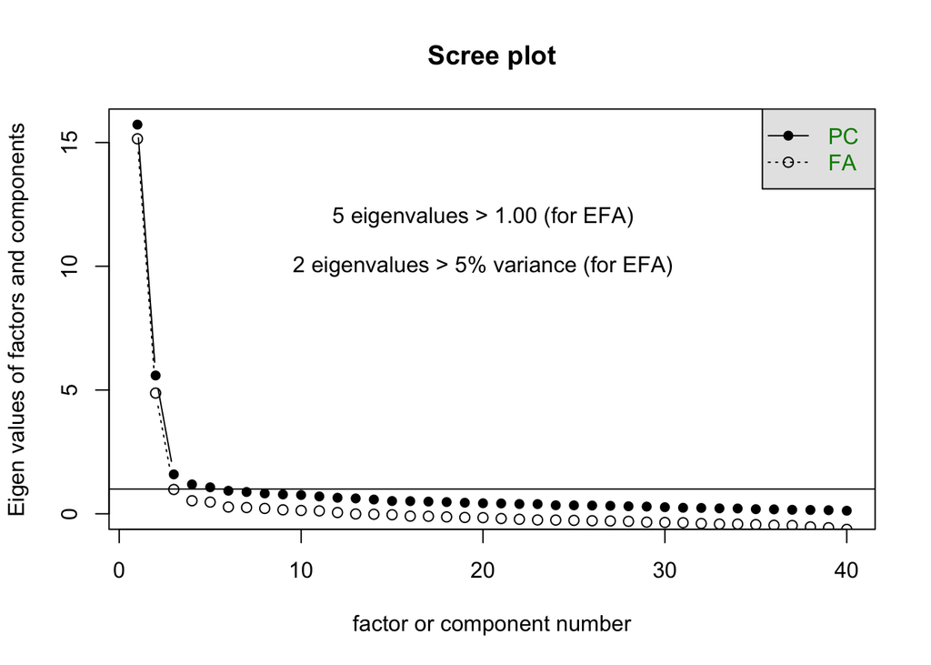

#### Step 2: Run EFA without rotation

```
## Factor Analysis using method =  minres
## Call: fa(r = d2_beetle, nfactors = 39, rotate = "none", fm = "minres",
##     cor = chosenCorType)
## Standardized loadings (pattern matrix) based upon correlation matrix
##                 MR1   MR2   MR3   MR4   MR5   MR7   MR6  MR10   MR8   MR9
## happy          0.84 -0.01 -0.27 -0.14 -0.12  0.01  0.06 -0.10  0.13 -0.04
## depressed      0.77 -0.26 -0.08 -0.18 -0.18 -0.02 -0.27 -0.02  0.28  0.00
## fear           0.56  0.38 -0.11 -0.12  0.10  0.09 -0.02 -0.05 -0.04  0.01
## angry          0.67  0.05 -0.12 -0.33 -0.01  0.35  0.11  0.06 -0.14 -0.28
## calm           0.75  0.27 -0.34 -0.04 -0.03 -0.24  0.21  0.12 -0.27 -0.10
## sounds         0.38  0.57  0.11  0.03  0.04  0.06  0.06  0.00  0.03 -0.02
## seeing         0.34  0.77  0.23 -0.06  0.25 -0.14 -0.02 -0.24  0.12 -0.21
## temperature    0.30  0.60  0.09 -0.14  0.16 -0.10  0.00  0.27  0.13  0.05
## odors          0.36  0.61  0.13 -0.12  0.16 -0.04  0.01 -0.12  0.07  0.11
## depth          0.37  0.33  0.13  0.07  0.05  0.00  0.07  0.00 -0.03  0.06
## computations   0.52 -0.23  0.26  0.07 -0.06 -0.12 -0.04  0.00 -0.03  0.09
## thoughts       0.77  0.05 -0.17  0.36  0.11 -0.07 -0.12 -0.01  0.11 -0.16
## reasoning      0.72 -0.08  0.06  0.51  0.03  0.03 -0.03  0.12 -0.01  0.04
## remembering    0.56  0.33  0.05  0.18 -0.04 -0.03  0.03 -0.05  0.04  0.10
## beliefs        0.60 -0.31  0.17  0.08 -0.02 -0.11 -0.02 -0.02  0.18  0.03
## hungry         0.21  0.69  0.05 -0.19  0.31 -0.07 -0.02  0.43  0.14  0.26
## tired          0.56  0.41 -0.03 -0.04 -0.05  0.10  0.09  0.06  0.02 -0.01
## pain           0.41  0.48 -0.06 -0.07  0.08  0.05 -0.04  0.19 -0.03  0.01
## nauseated      0.58  0.08 -0.01 -0.12  0.00 -0.07  0.04 -0.05  0.02 -0.01
## safe           0.61  0.33 -0.24  0.12 -0.01  0.09  0.33 -0.25  0.11  0.41
## love           0.75 -0.24  0.04 -0.06 -0.11 -0.12 -0.21  0.17  0.20 -0.06
## recognizing    0.65  0.08  0.09 -0.05 -0.10  0.00  0.00 -0.05 -0.14  0.00
## communicating  0.53  0.53  0.43 -0.08 -0.38  0.07 -0.11 -0.01 -0.20  0.07
## guilt          0.67 -0.47  0.26 -0.10  0.03 -0.23  0.09 -0.07 -0.04  0.14
## disrespected   0.63 -0.41  0.10 -0.21  0.34  0.32  0.05 -0.01 -0.02  0.06
## free_will      0.52  0.32  0.12  0.11  0.03  0.11 -0.16  0.03  0.01 -0.13
## choices        0.57  0.38  0.08  0.08 -0.06  0.10  0.02 -0.02  0.00  0.01
## self_restraint 0.68 -0.22  0.13  0.09  0.17  0.05  0.04  0.08 -0.13 -0.01
## intentions     0.54  0.42  0.16  0.32 -0.18  0.32  0.16  0.09  0.16 -0.05
## goal           0.48  0.43  0.09  0.06 -0.07  0.10  0.11  0.03  0.12 -0.05
## conscious      0.53  0.37 -0.20  0.13  0.11  0.05 -0.09  0.00  0.03  0.04
## self_aware     0.74  0.03 -0.18  0.06  0.20  0.11 -0.45 -0.07 -0.27  0.11
## desires        0.66  0.14 -0.01  0.12 -0.05  0.05  0.07  0.16  0.09 -0.14
## embarrassed    0.63 -0.48  0.25 -0.04 -0.05 -0.21  0.09  0.05  0.03  0.13
## emo_recog      0.78 -0.26  0.19  0.08  0.06 -0.16  0.00 -0.14 -0.14  0.02
```

[output cut: 227 more lines]

```
## Correlation of scores with factors             0.99 0.98 0.98 0.90 0.91
## Multiple R square of scores with factors       0.97 0.97 0.97 0.82 0.83
## Minimum correlation of possible factor scores  0.95 0.94 0.94 0.63 0.66
##                                                MR29 MR28 MR23 MR21 MR33
## Correlation of scores with factors             0.92 0.94 0.97 0.98 0.87
## Multiple R square of scores with factors       0.84 0.88 0.94 0.96 0.76
## Minimum correlation of possible factor scores  0.68 0.76 0.88 0.91 0.52
##                                                MR32 MR22 MR36 MR34 MR35
## Correlation of scores with factors             0.88 0.97 0.80 0.85 0.84
## Multiple R square of scores with factors       0.77 0.94 0.64 0.71 0.71
## Minimum correlation of possible factor scores  0.55 0.89 0.27 0.43 0.42
##                                                MR37 MR38  MR39
## Correlation of scores with factors             0.77 0.74  0.40
## Multiple R square of scores with factors       0.59 0.55  0.16
## Minimum correlation of possible factor scores  0.18 0.11 -0.68
```

#### Step 3: Run EFA with oblimin rotation

```
## Factor Analysis using method =  minres
## Call: fa(r = d2_beetle, nfactors = nfactors_d2_beetle, rotate = "oblimin",
##     fm = "minres", cor = chosenCorType)
## Standardized loadings (pattern matrix) based upon correlation matrix
##                  MR1   MR2   h2   u2 com
## happy           0.62  0.35 0.66 0.34 1.6
## depressed       0.76  0.08 0.62 0.38 1.0
## fear            0.14  0.64 0.48 0.52 1.1
## angry           0.45  0.35 0.43 0.57 1.9
## calm            0.37  0.55 0.58 0.42 1.8
## sounds         -0.13  0.75 0.51 0.49 1.1
## seeing         -0.23  0.80 0.56 0.44 1.2
## temperature    -0.19  0.70 0.43 0.57 1.1
## odors          -0.14  0.72 0.48 0.52 1.1
## depth           0.06  0.51 0.28 0.72 1.0
## computations    0.61 -0.04 0.36 0.64 1.0
## thoughts        0.53  0.39 0.58 0.42 1.8
## reasoning       0.60  0.23 0.50 0.50 1.3
## remembering     0.21  0.56 0.43 0.57 1.3
## beliefs         0.72 -0.07 0.49 0.51 1.0
## hungry         -0.30  0.71 0.46 0.54 1.3
## tired           0.12  0.67 0.51 0.49 1.1
## pain           -0.06  0.67 0.43 0.57 1.0
## nauseated       0.40  0.34 0.37 0.63 1.9
## safe            0.23  0.57 0.46 0.54 1.3
## love            0.75  0.07 0.60 0.40 1.0
## recognizing     0.47  0.34 0.44 0.56 1.8
## communicating   0.09  0.66 0.48 0.52 1.0
## guilt           0.88 -0.20 0.70 0.30 1.1
## disrespected    0.74 -0.09 0.51 0.49 1.0
## free_will       0.16  0.54 0.37 0.63 1.2
## choices         0.17  0.64 0.51 0.49 1.1
## self_restraint  0.68  0.07 0.50 0.50 1.0
## intentions      0.13  0.61 0.44 0.56 1.1
## goal            0.07  0.61 0.41 0.59 1.0
## conscious       0.12  0.62 0.44 0.56 1.1
## self_aware      0.52  0.34 0.50 0.50 1.7
## desires         0.40  0.45 0.48 0.52 2.0
## embarrassed     0.85 -0.22 0.65 0.35 1.1
## emo_recog       0.80  0.05 0.67 0.33 1.0
```

[output cut: 24 more lines]

```
## The root mean square of the residuals (RMSR) is  0.05
## The df corrected root mean square of the residuals is  0.05
##
## The harmonic number of observations is  202 with the empirical chi square  735.39  with prob <  0.18
## The total number of observations was  202  with MLE Chi Square =  1251.92  with prob <  1.2e-33
##
## Tucker Lewis Index of factoring reliability =  0.872
## RMSEA index =  0.068  and the 90 % confidence intervals are  0.057 NA
## BIC =  -2469.17
## Fit based upon off diagonal values = 0.99
## Measures of factor score adequacy
##                                                 MR1  MR2
## Correlation of scores with factors             0.98 0.97
## Multiple R square of scores with factors       0.96 0.95
## Minimum correlation of possible factor scores  0.92 0.89
```

back to TOC

##### Factor 1

Study 2, BEETLE condition: Rotated Factor 1

|  | F1 |
| --- | --- |
| guilt | 0.8803545 |
| embarrassed | 0.8542553 |
| pride | 0.8134527 |
| emo_recog | 0.8016504 |
| morality | 0.7796767 |
| depressed | 0.7579188 |
| love | 0.7475632 |
| disrespected | 0.7378570 |
| beliefs | 0.7237554 |
| self_restraint | 0.6782371 |
| personality | 0.6622739 |
| happy | 0.6247966 |
| computations | 0.6148052 |
| reasoning | 0.5981875 |
| joy | 0.5595771 |
| thoughts | 0.5322581 |
| self_aware | 0.5203008 |
| recognizing | 0.4713972 |
| angry | 0.4472759 |
| pleasure | 0.4348482 |
| nauseated | 0.4041003 |
| desires | 0.4037717 |
| calm | 0.3731078 |
| safe | 0.2282987 |
| remembering | 0.2128353 |
| choices | 0.1723475 |
| free_will | 0.1553498 |
| fear | 0.1365334 |
| intentions | 0.1298634 |
| tired | 0.1208708 |
| conscious | 0.1178029 |
| communicating | 0.0861402 |
| goal | 0.0719750 |
| depth | 0.0557840 |
| pain | -0.0555170 |
| sounds | -0.1254721 |
| odors | -0.1419015 |
| temperature | -0.1855424 |
| seeing | -0.2252028 |
| hungry | -0.3005706 |

##### Factor 2

Study 2, BEETLE condition: Rotated Factor 2

|  | F2 |
| --- | --- |
| seeing | 0.7955594 |
| sounds | 0.7456164 |
| odors | 0.7248234 |
| hungry | 0.7141059 |
| temperature | 0.6961565 |
| pain | 0.6724988 |
| tired | 0.6683506 |
| communicating | 0.6559583 |
| fear | 0.6369419 |
| choices | 0.6367620 |
| conscious | 0.6160587 |
| goal | 0.6141723 |
| intentions | 0.6118067 |
| safe | 0.5707932 |
| remembering | 0.5551369 |
| calm | 0.5524617 |
| free_will | 0.5412922 |
| depth | 0.5052081 |
| pleasure | 0.4770327 |
| desires | 0.4469858 |
| thoughts | 0.3920599 |
| joy | 0.3911016 |
| angry | 0.3532373 |
| happy | 0.3521854 |
| nauseated | 0.3410370 |
| recognizing | 0.3380248 |
| self_aware | 0.3379393 |
| personality | 0.2906303 |
| reasoning | 0.2260208 |
| depressed | 0.0840683 |
| self_restraint | 0.0740691 |
| love | 0.0740191 |
| emo_recog | 0.0526682 |
| computations | -0.0433805 |
| beliefs | -0.0706573 |
| disrespected | -0.0923191 |
| pride | -0.0935499 |
| morality | -0.1178541 |
| guilt | -0.1977198 |
| embarrassed | -0.2160513 |

##### Factor 3 (*not applicable*)

back to TOC

### EFA: ROBOT condition

#### Step 1: Determine how many factors to extract

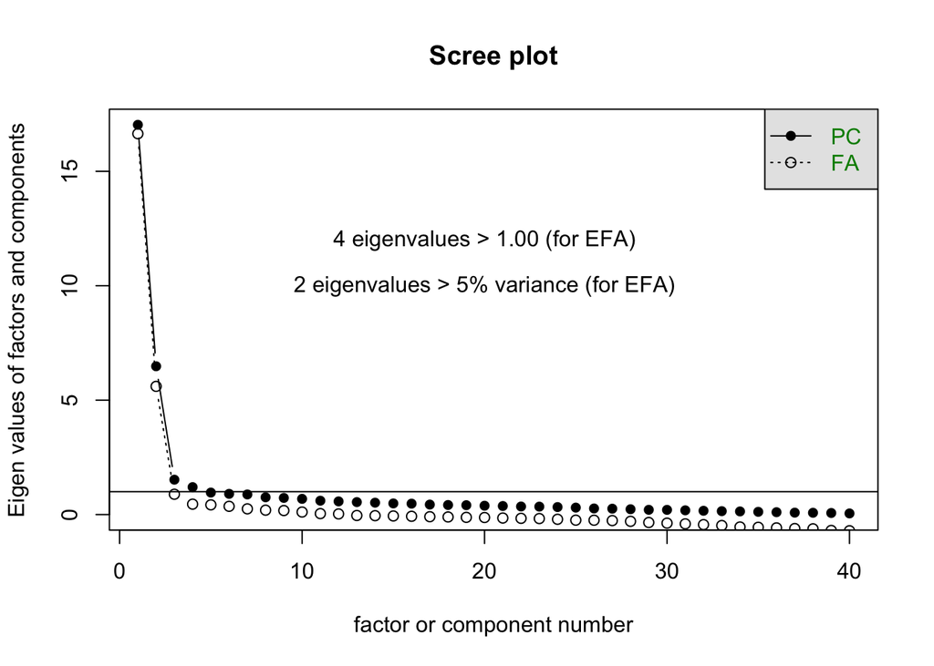

#### Step 2: Run EFA without rotation

```
## Factor Analysis using method =  minres
## Call: fa(r = d2_robot, nfactors = 39, rotate = "none", fm = "minres",
##     cor = chosenCorType)
## Standardized loadings (pattern matrix) based upon correlation matrix
##                  MR1   MR9  MR11  MR12  MR10   MR6  MR18   MR2   MR3  MR19
## happy           0.87  0.00  0.00  0.00  0.05 -0.04  0.00 -0.07  0.08 -0.01
## depressed       0.91 -0.09 -0.08  0.02  0.09  0.14  0.00 -0.13 -0.22  0.01
## fear            0.91  0.07 -0.04  0.02  0.02  0.12  0.01  0.13  0.04  0.00
## angry           0.87  0.09 -0.05  0.00 -0.04  0.00  0.01  0.09  0.09  0.00
## calm            0.55  0.16  0.10  0.04  0.04 -0.02  0.22  0.15  0.20 -0.14
## sounds         -0.08  0.43  0.26  0.33  0.26  0.14 -0.18  0.17  0.12 -0.30
## seeing          0.14  0.35  0.43  0.31  0.30  0.17 -0.11  0.13  0.16  0.02
## temperature     0.03  0.27  0.33  0.28  0.36  0.19 -0.15  0.05  0.15 -0.04
## odors           0.15  0.29  0.26  0.26  0.34  0.13 -0.13  0.01  0.07  0.11
## depth           0.06  0.28  0.23  0.26  0.23  0.21 -0.24  0.02  0.12  0.04
## computations   -0.19  0.32  0.28  0.26  0.23  0.28 -0.19  0.07  0.15 -0.34
## thoughts        0.58  0.10  0.17  0.09 -0.04  0.11  0.34  0.12  0.15 -0.01
## reasoning       0.26  0.31  0.29  0.27  0.13  0.17  0.00  0.05  0.12  0.24
## remembering     0.04  0.35  0.34  0.36  0.29  0.20 -0.08  0.10  0.12 -0.16
## beliefs         0.65  0.15  0.03  0.14 -0.02  0.20  0.08 -0.10  0.09 -0.07
## hungry          0.87  0.06 -0.06 -0.03  0.15 -0.13 -0.01 -0.36  0.05  0.00
## tired           0.80  0.23  0.00 -0.15 -0.03 -0.02  0.00 -0.04  0.18 -0.01
## pain            0.87 -0.12 -0.01  0.06  0.07 -0.06  0.02 -0.31  0.02 -0.01
## nauseated       0.86 -0.01  0.20  0.01 -0.21  0.01  0.00 -0.38  0.00  0.00
## safe            0.71  0.17  0.03 -0.05  0.08 -0.11  0.17  0.15  0.13  0.03
## love            0.89 -0.03 -0.04  0.14  0.00 -0.14  0.02  0.18  0.00  0.01
## recognizing     0.16  0.35  0.32  0.27  0.31  0.18 -0.08  0.09  0.12 -0.05
## communicating   0.08  0.31  0.35  0.32  0.27  0.25 -0.10  0.11  0.10 -0.11
## guilt           0.90 -0.17  0.03  0.10 -0.05  0.14 -0.02  0.15 -0.20 -0.02
## disrespected    0.88 -0.04  0.07 -0.13  0.16 -0.07  0.01  0.10 -0.05 -0.01
## free_will       0.52  0.06  0.01  0.16 -0.06  0.14  0.24 -0.02 -0.01 -0.04
## choices         0.11  0.34  0.24  0.38  0.24  0.14  0.02  0.10  0.20  0.06
## self_restraint  0.39  0.16  0.16  0.26  0.06  0.13  0.11  0.06  0.16  0.15
## intentions      0.48  0.23  0.13  0.15  0.07  0.16  0.20  0.10  0.07  0.03
## goal            0.13  0.33  0.37  0.32  0.30  0.16  0.10  0.17  0.14  0.01
## conscious       0.62  0.14 -0.01  0.12 -0.04  0.00  0.54  0.12  0.08 -0.09
## self_aware      0.52  0.22  0.12  0.16  0.02  0.14  0.33  0.20  0.00  0.03
## desires         0.84 -0.03 -0.09 -0.04 -0.08  0.26 -0.02 -0.01  0.35  0.00
## embarrassed     0.86  0.18 -0.01 -0.06 -0.11 -0.07 -0.01  0.05 -0.38  0.01
## emo_recog       0.56  0.15  0.18  0.15  0.20  0.11 -0.06  0.05  0.15  0.47
```

[output cut: 231 more lines]

```
## Correlation of scores with factors             0.96 0.98 0.97  0.68  0.68
## Multiple R square of scores with factors       0.91 0.96 0.95  0.46  0.46
## Minimum correlation of possible factor scores  0.83 0.91 0.89 -0.08 -0.09
##                                                 MR32 MR16  MR33  MR34
## Correlation of scores with factors              0.64 0.97  0.59  0.55
## Multiple R square of scores with factors        0.41 0.94  0.35  0.30
## Minimum correlation of possible factor scores  -0.18 0.87 -0.31 -0.40
##                                                 MR35  MR36  MR37  MR38
## Correlation of scores with factors              0.53  0.48  0.47  0.34
## Multiple R square of scores with factors        0.28  0.23  0.22  0.11
## Minimum correlation of possible factor scores  -0.44 -0.53 -0.56 -0.77
##                                                 MR39
## Correlation of scores with factors              0.30
## Multiple R square of scores with factors        0.09
## Minimum correlation of possible factor scores  -0.82
```

#### Step 3: Run EFA with oblimin rotation

```
## Factor Analysis using method =  minres
## Call: fa(r = d2_robot, nfactors = nfactors_d2_robot, rotate = "oblimin",
##     fm = "minres", cor = chosenCorType)
## Standardized loadings (pattern matrix) based upon correlation matrix
##                  MR1   MR2   h2   u2 com
## happy           0.86 -0.03 0.74 0.26 1.0
## depressed       0.92 -0.08 0.82 0.18 1.0
## fear            0.91  0.01 0.83 0.17 1.0
## angry           0.86  0.01 0.73 0.27 1.0
## calm            0.53  0.21 0.36 0.64 1.3
## sounds         -0.19  0.71 0.49 0.51 1.1
## seeing          0.04  0.73 0.54 0.46 1.0
## temperature    -0.07  0.66 0.42 0.58 1.0
## odors           0.07  0.57 0.35 0.65 1.0
## depth          -0.03  0.56 0.31 0.69 1.0
## computations   -0.29  0.65 0.44 0.56 1.4
## thoughts        0.57  0.26 0.44 0.56 1.4
## reasoning       0.19  0.57 0.40 0.60 1.2
## remembering    -0.06  0.73 0.52 0.48 1.0
## beliefs         0.63  0.19 0.47 0.53 1.2
## hungry          0.86 -0.09 0.72 0.28 1.0
## tired           0.79  0.00 0.63 0.37 1.0
## pain            0.86 -0.07 0.73 0.27 1.0
## nauseated       0.86 -0.10 0.72 0.28 1.0
## safe            0.71  0.09 0.53 0.47 1.0
## love            0.89 -0.05 0.77 0.23 1.0
## recognizing     0.07  0.71 0.52 0.48 1.0
## communicating  -0.03  0.73 0.53 0.47 1.0
## guilt           0.91 -0.05 0.81 0.19 1.0
## disrespected    0.87  0.00 0.76 0.24 1.0
## free_will       0.51  0.12 0.30 0.70 1.1
## choices         0.02  0.72 0.52 0.48 1.0
## self_restraint  0.35  0.40 0.32 0.68 2.0
## intentions      0.44  0.38 0.39 0.61 2.0
## goal            0.03  0.74 0.55 0.45 1.0
## conscious       0.62  0.16 0.45 0.55 1.1
## self_aware      0.50  0.35 0.42 0.58 1.8
## desires         0.82  0.08 0.71 0.29 1.0
## embarrassed     0.86 -0.06 0.73 0.27 1.0
## emo_recog       0.52  0.35 0.46 0.54 1.8
```

[output cut: 24 more lines]

```
## The root mean square of the residuals (RMSR) is  0.05
## The df corrected root mean square of the residuals is  0.05
##
## The harmonic number of observations is  204 with the empirical chi square  661.88  with prob <  0.85
## The total number of observations was  204  with MLE Chi Square =  1547.07  with prob <  1.1e-65
##
## Tucker Lewis Index of factoring reliability =  0.854
## RMSEA index =  0.083  and the 90 % confidence intervals are  0.072 NA
## BIC =  -2180.93
## Fit based upon off diagonal values = 0.99
## Measures of factor score adequacy
##                                                 MR1  MR2
## Correlation of scores with factors             0.99 0.96
## Multiple R square of scores with factors       0.98 0.93
## Minimum correlation of possible factor scores  0.97 0.85
```

back to TOC

##### Factor 1

Study 2, ROBOT condition: Rotated Factor 1

|  | F1 |
| --- | --- |
| pride | 0.9305553 |
| depressed | 0.9178856 |
| fear | 0.9112457 |
| guilt | 0.9101970 |
| love | 0.8869788 |
| joy | 0.8732872 |
| disrespected | 0.8711814 |
| happy | 0.8648991 |
| embarrassed | 0.8632728 |
| nauseated | 0.8618791 |
| pain | 0.8617204 |
| hungry | 0.8594841 |
| angry | 0.8555406 |
| pleasure | 0.8553076 |
| desires | 0.8249609 |
| tired | 0.7932471 |
| safe | 0.7115840 |
| beliefs | 0.6295444 |
| conscious | 0.6211557 |
| thoughts | 0.5681323 |
| calm | 0.5308524 |
| emo_recog | 0.5227627 |
| free_will | 0.5118449 |
| self_aware | 0.4970889 |
| personality | 0.4891627 |
| intentions | 0.4388387 |
| morality | 0.3956186 |
| self_restraint | 0.3472334 |
| reasoning | 0.1926771 |
| recognizing | 0.0663543 |
| odors | 0.0661537 |
| seeing | 0.0365123 |
| goal | 0.0316102 |
| choices | 0.0188257 |
| communicating | -0.0266782 |
| depth | -0.0275297 |
| remembering | -0.0625296 |
| temperature | -0.0682218 |
| sounds | -0.1939118 |
| computations | -0.2922289 |

##### Factor 2

Study 2, ROBOT condition: Rotated Factor 2

|  | F2 |
| --- | --- |
| goal | 0.7390096 |
| seeing | 0.7308093 |
| communicating | 0.7303912 |
| remembering | 0.7291375 |
| choices | 0.7165656 |
| sounds | 0.7081143 |
| recognizing | 0.7059270 |
| temperature | 0.6556088 |
| computations | 0.6460425 |
| odors | 0.5740639 |
| reasoning | 0.5700562 |
| depth | 0.5649050 |
| morality | 0.4322313 |
| self_restraint | 0.3954423 |
| intentions | 0.3786108 |
| emo_recog | 0.3533344 |
| self_aware | 0.3450476 |
| personality | 0.3204362 |
| thoughts | 0.2624261 |
| calm | 0.2087978 |
| beliefs | 0.1871683 |
| conscious | 0.1612716 |
| free_will | 0.1206103 |
| safe | 0.0860659 |
| desires | 0.0801130 |
| fear | 0.0080766 |
| angry | 0.0076457 |
| disrespected | 0.0011771 |
| tired | -0.0044641 |
| joy | -0.0052948 |
| pride | -0.0250570 |
| pleasure | -0.0265126 |
| happy | -0.0330416 |
| love | -0.0499342 |
| guilt | -0.0549815 |
| embarrassed | -0.0554178 |
| pain | -0.0711324 |
| depressed | -0.0774049 |
| hungry | -0.0906640 |
| nauseated | -0.0959285 |

##### Factor 3 (*not applicable*)

back to TOC

### EFA: ALL conditions

#### Step 1: Determine how many factors to extract

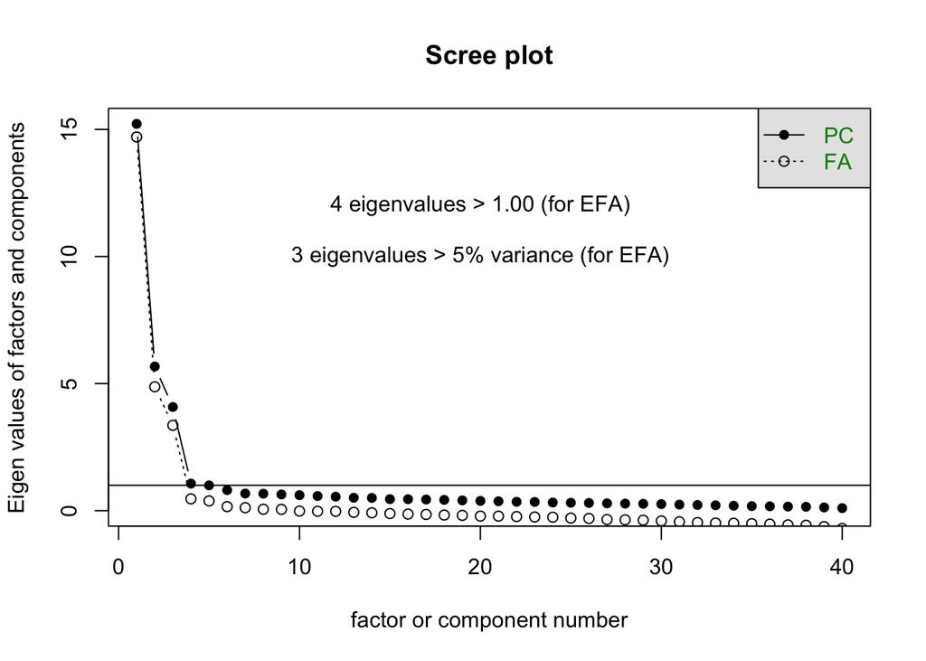

#### Step 2: Run EFA without rotation

```
## Factor Analysis using method =  minres
## Call: fa(r = d2_all, nfactors = 39, rotate = "none", fm = "minres",
##     cor = chosenCorType)
## Standardized loadings (pattern matrix) based upon correlation matrix
##                  MR1   MR2   MR9   MR3   MR4   MR5  MR10   MR7  MR11  MR13
## happy           0.84  0.34 -0.03  0.16 -0.27  0.17  0.02  0.04  0.00 -0.01
## depressed       0.72  0.44 -0.02 -0.11 -0.05  0.06  0.06 -0.05  0.01  0.00
## fear            0.81 -0.18  0.12  0.03  0.06  0.11  0.04  0.03 -0.11  0.14
## angry           0.76  0.14  0.09  0.01  0.02  0.03 -0.06 -0.02 -0.06 -0.01
## calm            0.71  0.15  0.12  0.22  0.04  0.03  0.03  0.09 -0.04  0.14
## sounds          0.04  0.11  0.24  0.38  0.32  0.33  0.13  0.21 -0.01 -0.10
## seeing          0.32 -0.09  0.36  0.21  0.29  0.30  0.19  0.26  0.13 -0.16
## temperature     0.20 -0.05  0.17  0.27  0.33  0.29  0.16  0.26  0.18 -0.15
## odors           0.40 -0.14  0.25  0.13  0.28  0.25  0.27  0.22  0.23 -0.16
## depth           0.07  0.17  0.23  0.20  0.32  0.25  0.12  0.17  0.14 -0.04
## computations   -0.54  0.66 -0.12  0.28  0.34  0.23 -0.03  0.07 -0.03  0.02
## thoughts        0.69  0.19  0.30  0.09  0.10  0.03 -0.07  0.04 -0.03  0.25
## reasoning       0.10  0.47  0.32  0.15  0.25  0.19 -0.03  0.09  0.20  0.07
## remembering    -0.06  0.40  0.26  0.33  0.32  0.25  0.12  0.17  0.09 -0.06
## beliefs         0.38  0.46  0.10 -0.17  0.11  0.15 -0.09  0.08  0.07  0.12
## hungry          0.79 -0.54 -0.07 -0.13  0.04  0.09 -0.02  0.23  0.01  0.01
## tired           0.81 -0.26  0.16  0.06  0.10  0.05  0.02  0.03 -0.31 -0.01
## pain            0.83 -0.44 -0.02  0.00  0.18  0.18  0.01 -0.22  0.01  0.00
## nauseated       0.72  0.05  0.05  0.00  0.05  0.00 -0.04  0.04 -0.01  0.01
## safe            0.76 -0.02  0.19  0.08 -0.02  0.06 -0.01  0.10 -0.06  0.22
## love            0.69  0.38  0.03 -0.10  0.01 -0.01 -0.13  0.01  0.02 -0.03
## recognizing    -0.07  0.54  0.27  0.26  0.23  0.21  0.07  0.10  0.17 -0.05
## communicating   0.15  0.22  0.29  0.28  0.39  0.28  0.20  0.17  0.06 -0.19
## guilt           0.57  0.63 -0.01 -0.50  0.12 -0.05  0.05  0.00 -0.01  0.00
## disrespected    0.55  0.43  0.09 -0.22  0.00  0.10 -0.26 -0.05  0.08  0.02
## free_will       0.69 -0.18  0.23  0.04  0.12  0.12 -0.05  0.07 -0.32 -0.25
## choices         0.27  0.17  0.40  0.32  0.30  0.20  0.07  0.19  0.07 -0.09
## self_restraint  0.31  0.40  0.28 -0.04  0.17  0.09  0.00  0.06  0.11  0.08
## intentions      0.58 -0.02  0.36  0.09  0.17  0.17 -0.05  0.14 -0.11  0.02
## goal            0.21  0.19  0.36  0.28  0.26  0.22  0.18  0.25  0.11 -0.05
## conscious       0.73 -0.15  0.27  0.08  0.04  0.05  0.03  0.08 -0.10  0.27
## self_aware      0.62  0.22  0.24  0.08  0.11  0.09 -0.01  0.06  0.02  0.22
## desires         0.78  0.05  0.11  0.08  0.11  0.05 -0.15  0.04  0.01  0.08
## embarrassed     0.53  0.53 -0.01 -0.32  0.04  0.04 -0.19 -0.01  0.08 -0.06
## emo_recog       0.38  0.53  0.24 -0.07  0.16  0.13 -0.07  0.05  0.21  0.08
```

[output cut: 231 more lines]

```
## Correlation of scores with factors              0.69  0.64  0.62  0.60
## Multiple R square of scores with factors        0.48  0.41  0.39  0.36
## Minimum correlation of possible factor scores  -0.04 -0.17 -0.22 -0.27
##                                                 MR30  MR31  MR32  MR33
## Correlation of scores with factors              0.58  0.56  0.53  0.50
## Multiple R square of scores with factors        0.34  0.32  0.28  0.25
## Minimum correlation of possible factor scores  -0.32 -0.37 -0.43 -0.51
##                                                 MR35  MR34  MR36  MR37
## Correlation of scores with factors              0.45  0.46  0.35  0.31
## Multiple R square of scores with factors        0.20  0.22  0.12  0.10
## Minimum correlation of possible factor scores  -0.60 -0.57 -0.75 -0.81
##                                                 MR38  MR39
## Correlation of scores with factors              0.28  0.22
## Multiple R square of scores with factors        0.08  0.05
## Minimum correlation of possible factor scores  -0.84 -0.91
```

#### Step 3: Run EFA with oblimin rotation

```
## Factor Analysis using method =  minres
## Call: fa(r = d2_all, nfactors = nfactors_d2_all, rotate = "oblimin",
##     fm = "minres", cor = chosenCorType)
## Standardized loadings (pattern matrix) based upon correlation matrix
##                  MR1   MR2   MR3   h2   u2 com
## happy           0.64  0.38  0.04 0.72 0.28 1.6
## depressed       0.78  0.20 -0.07 0.71 0.29 1.1
## fear            0.17  0.77  0.09 0.75 0.25 1.1
## angry           0.47  0.47  0.05 0.61 0.39 2.0
## calm            0.35  0.45  0.23 0.55 0.45 2.4
## sounds         -0.19  0.03  0.75 0.52 0.48 1.1
## seeing         -0.18  0.36  0.68 0.56 0.44 1.7
## temperature    -0.20  0.25  0.64 0.43 0.57 1.5
## odors          -0.13  0.45  0.52 0.45 0.55 2.1
## depth          -0.02 -0.02  0.59 0.34 0.66 1.0
## computations    0.16 -0.83  0.43 0.79 0.21 1.6
## thoughts        0.46  0.39  0.21 0.58 0.42 2.4
## reasoning       0.37 -0.27  0.49 0.47 0.53 2.5
## remembering     0.07 -0.29  0.72 0.58 0.42 1.3
## beliefs         0.65 -0.08  0.09 0.44 0.56 1.1
## hungry         -0.07  0.95 -0.06 0.86 0.14 1.0
## tired           0.10  0.82  0.10 0.77 0.23 1.1
## pain            0.01  0.90  0.02 0.82 0.18 1.0
## nauseated       0.38  0.51  0.04 0.54 0.46 1.9
## safe            0.27  0.61  0.14 0.62 0.38 1.5
## love            0.74  0.20 -0.04 0.66 0.34 1.1
## recognizing     0.26 -0.42  0.61 0.59 0.41 2.2
## communicating  -0.01  0.01  0.73 0.54 0.46 1.0
## guilt           0.90 -0.06 -0.13 0.73 0.27 1.1
## disrespected    0.78  0.04 -0.08 0.60 0.40 1.0
## free_will       0.12  0.67  0.15 0.56 0.44 1.2
## choices         0.05  0.12  0.69 0.53 0.47 1.1
## self_restraint  0.49 -0.07  0.27 0.37 0.63 1.6
## intentions      0.17  0.48  0.35 0.50 0.50 2.1
## goal            0.01  0.08  0.69 0.49 0.51 1.0
## conscious       0.17  0.68  0.16 0.62 0.38 1.2
## self_aware      0.45  0.31  0.23 0.52 0.48 2.3
## desires         0.40  0.54  0.12 0.64 0.36 2.0
## embarrassed     0.86 -0.05 -0.14 0.67 0.33 1.1
## emo_recog       0.66 -0.14  0.25 0.55 0.45 1.4
```

[output cut: 25 more lines]

```
## The root mean square of the residuals (RMSR) is  0.03
## The df corrected root mean square of the residuals is  0.03
##
## The harmonic number of observations is  406 with the empirical chi square  607.3  with prob <  0.94
## The total number of observations was  406  with MLE Chi Square =  1526.24  with prob <  6.5e-70
##
## Tucker Lewis Index of factoring reliability =  0.916
## RMSEA index =  0.059  and the 90 % confidence intervals are  0.053 0.06
## BIC =  -2455.97
## Fit based upon off diagonal values = 0.99
## Measures of factor score adequacy
##                                                 MR1  MR2  MR3
## Correlation of scores with factors             0.98 0.98 0.96
## Multiple R square of scores with factors       0.96 0.97 0.92
## Minimum correlation of possible factor scores  0.92 0.93 0.85
```

back to TOC

##### Factor 1

Study 2, ALL conditions: Rotated Factor 1

|  | F1 |
| --- | --- |
| guilt | 0.9018117 |
| embarrassed | 0.8644501 |
| pride | 0.8512502 |
| disrespected | 0.7816774 |
| depressed | 0.7768355 |
| love | 0.7414486 |
| emo_recog | 0.6627206 |
| beliefs | 0.6530539 |
| happy | 0.6389639 |
| joy | 0.5955045 |
| personality | 0.5895859 |
| morality | 0.5678485 |
| self_restraint | 0.4896610 |
| angry | 0.4699806 |
| thoughts | 0.4556764 |
| self_aware | 0.4531171 |
| desires | 0.3967682 |
| pleasure | 0.3961616 |
| nauseated | 0.3817812 |
| reasoning | 0.3696592 |
| calm | 0.3545488 |
| safe | 0.2740405 |
| recognizing | 0.2635986 |
| fear | 0.1748140 |
| intentions | 0.1677811 |
| conscious | 0.1661887 |
| computations | 0.1605288 |
| free_will | 0.1214247 |
| tired | 0.0998412 |
| remembering | 0.0669193 |
| choices | 0.0506938 |
| pain | 0.0109853 |
| goal | 0.0097885 |
| communicating | -0.0058206 |
| depth | -0.0221118 |
| hungry | -0.0701970 |
| odors | -0.1325338 |
| seeing | -0.1758959 |
| sounds | -0.1907316 |
| temperature | -0.2031845 |

##### Factor 2

Study 2, ALL conditions: Rotated Factor 2

|  | F2 |
| --- | --- |
| hungry | 0.9477598 |
| pain | 0.8997743 |
| tired | 0.8211861 |
| fear | 0.7720673 |
| conscious | 0.6809673 |
| free_will | 0.6666312 |
| safe | 0.6132382 |
| pleasure | 0.5988310 |
| desires | 0.5396944 |
| nauseated | 0.5082342 |
| intentions | 0.4794387 |
| angry | 0.4746162 |
| calm | 0.4519300 |
| odors | 0.4513555 |
| thoughts | 0.3896041 |
| joy | 0.3884269 |
| happy | 0.3754179 |
| seeing | 0.3633246 |
| self_aware | 0.3113616 |
| temperature | 0.2470464 |
| love | 0.1968049 |
| depressed | 0.1953708 |
| choices | 0.1215030 |
| goal | 0.0803831 |
| pride | 0.0435385 |
| disrespected | 0.0432014 |
| sounds | 0.0329935 |
| communicating | 0.0125797 |
| personality | 0.0087852 |
| depth | -0.0216847 |
| embarrassed | -0.0526589 |
| guilt | -0.0599803 |
| self_restraint | -0.0705879 |
| beliefs | -0.0789678 |
| emo_recog | -0.1375540 |
| reasoning | -0.2659083 |
| remembering | -0.2857466 |
| morality | -0.2909780 |
| recognizing | -0.4248210 |
| computations | -0.8272856 |

##### Factor 3

Study 2, ALL conditions: Rotated Factor 3

|  | F3 |
| --- | --- |
| sounds | 0.7505277 |
| communicating | 0.7324933 |
| remembering | 0.7179818 |
| choices | 0.6876736 |
| goal | 0.6864950 |
| seeing | 0.6753770 |
| temperature | 0.6380509 |
| recognizing | 0.6097092 |
| depth | 0.5895839 |
| odors | 0.5173410 |
| reasoning | 0.4918902 |
| computations | 0.4347000 |
| intentions | 0.3500669 |
| personality | 0.2837250 |
| self_restraint | 0.2716401 |
| morality | 0.2705058 |
| emo_recog | 0.2495774 |
| calm | 0.2327532 |
| self_aware | 0.2258684 |
| thoughts | 0.2055088 |
| conscious | 0.1560888 |
| free_will | 0.1466452 |
| safe | 0.1388006 |
| desires | 0.1230747 |
| tired | 0.0989842 |
| fear | 0.0949720 |
| beliefs | 0.0927408 |
| pleasure | 0.0785267 |
| joy | 0.0781520 |
| angry | 0.0477393 |
| happy | 0.0449535 |
| nauseated | 0.0353175 |
| pain | 0.0157851 |
| love | -0.0444002 |
| hungry | -0.0622055 |
| depressed | -0.0654152 |
| disrespected | -0.0843699 |
| pride | -0.0904020 |
| guilt | -0.1296249 |
| embarrassed | -0.1366754 |

back to TOC

## Confirmatory factor analysis

### CFA: All conditions

#### ModelWDM: Theoretical, three factors (SOCIAL-EMOTIONAL, BIOLOGICAL, PERCEPTUAL; see Weisman et al., 2015)

#### ModelGGW: Theoretical, two factors (AGENCY, EXPERIENCE; see Gray et al., 2007)

#### Compare models (not yet implemented)

```r
# MODELS HAVE DIFFERENT SETS OF VARIABLES, MIGHT NOT WORK
# # compare models (iff continuous and ML)
# customVuong(chosenDD = d2_all_fitDD,
#             chosenWDM = d2_all_fitWDM,
#             chosenGGW = d2_all_fitGGW)
```

back to TOC

# Study 3 (2016-01-10, 2 conditions, within-subjects)

## Demographics

Study 3: Exclusion

| did_not_finish | failed_catch_trial | did_not_provide_yob | too_young | TOTAL_excluded | TOTAL_participated | OVERALL_TOTAL |
| --- | --- | --- | --- | --- | --- | --- |
| 13 | 7 | 4 | 0 | 24 | 400 | 424 |

Study 3: Sample size

[output not shown]

Study 3: Study duration (minutes)

| condition | min_duration | max_duration | median_duration | mean_duration | sd_duration |
| --- | --- | --- | --- | --- | --- |
| within-subjects | 1.33 | 36.43 | 5.46 | 6.44 | 3.92 |

Study 3: Participant age (years; approximate)

| condition | min_age | max_age | median_age | mean_age | sd_age |
| --- | --- | --- | --- | --- | --- |
| within-subjects | 20 | 68 | 33 | 36.84 | 11.28 |

Study 3: Participant gender

| condition | m | f | other |
| --- | --- | --- | --- |
| all | 202 | 198 | 0 |

Study 3: Participant race/ethnicity

| condition | asian_east | asian_south | black | hispanic | multiracial | white |
| --- | --- | --- | --- | --- | --- | --- |
| all | 30 | 4 | 38 | 16 | 22 | 290 |

Study 3: Participant religion

| condition | buddhism | christianity | islam | none | other | other_prefno |
| --- | --- | --- | --- | --- | --- | --- |
| all | 10 | 176 | 6 | 190 | 6 | 12 |

back to TOC

## Exploratory factor analysis

### EFA: ALL conditions

#### Step 1: Determine how many factors to extract

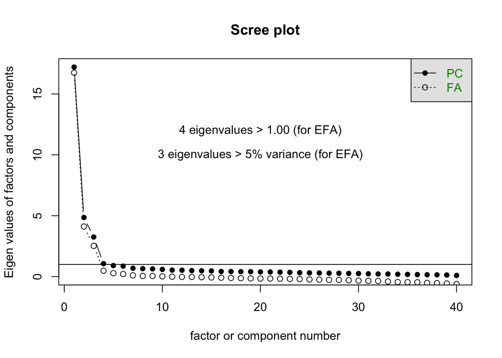

#### Step 2: Run EFA without rotation

```
## Factor Analysis using method =  minres
## Call: fa(r = d3_all, nfactors = 39, rotate = "none", fm = "minres",
##     cor = chosenCorType)
## Standardized loadings (pattern matrix) based upon correlation matrix
##                  MR1   MR2   MR8   MR9   MR7   MR3  MR11  MR13  MR10   MR4
## happy           0.85  0.39  0.00 -0.03 -0.13 -0.20  0.00  0.00 -0.01  0.13
## depressed       0.68  0.34  0.04  0.36  0.06 -0.09  0.06  0.08 -0.02 -0.01
## fear            0.85 -0.08  0.01 -0.01 -0.02  0.02  0.14 -0.08  0.05  0.04
## angry           0.79  0.22 -0.02  0.14  0.00  0.05  0.09 -0.02  0.04  0.02
## calm            0.78  0.14  0.10 -0.02  0.07  0.03  0.07 -0.10  0.10  0.01
## sounds          0.23  0.07  0.47 -0.32  0.18  0.03  0.16  0.17  0.20  0.13
## seeing          0.35 -0.09  0.44 -0.25  0.12  0.06  0.05  0.14  0.17  0.13
## temperature     0.38 -0.09  0.50 -0.27  0.11  0.09  0.13  0.24  0.02  0.10
## odors           0.52 -0.17  0.36 -0.12  0.07  0.02 -0.01  0.20  0.16  0.09
## depth           0.29  0.10  0.48 -0.11  0.19  0.16  0.11  0.14  0.06  0.00
## computations   -0.58  0.58  0.25 -0.05  0.17  0.15 -0.05 -0.05 -0.40  0.03
## thoughts        0.74  0.22  0.12  0.00  0.17  0.09 -0.07 -0.28  0.14  0.15
## reasoning       0.17  0.48  0.44  0.00  0.25  0.10 -0.05 -0.10  0.07  0.17
## remembering     0.06  0.38  0.49 -0.12  0.20  0.20  0.10  0.04  0.08  0.02
## beliefs         0.43  0.39  0.03  0.29  0.14  0.09 -0.16  0.16 -0.02  0.07
## hungry          0.82 -0.49  0.07  0.01 -0.05 -0.15 -0.02 -0.01 -0.03 -0.05
## tired           0.85 -0.20  0.01  0.05  0.03 -0.02  0.16  0.15 -0.03 -0.01
## pain            0.85 -0.43  0.01  0.01  0.06 -0.09 -0.01  0.00 -0.01  0.11
## nauseated       0.79  0.04  0.01  0.18  0.08 -0.01  0.31  0.00 -0.03  0.00
## safe            0.77 -0.07  0.08  0.04  0.04 -0.01  0.07 -0.13  0.09  0.08
## love            0.73  0.30  0.04  0.33  0.16 -0.02  0.27 -0.14 -0.06  0.06
## recognizing     0.01  0.51  0.53 -0.07  0.21  0.08  0.04 -0.04  0.15  0.09
## communicating   0.06  0.29  0.50 -0.07  0.15  0.09  0.03  0.06  0.12  0.06
## guilt           0.56  0.42  0.02  0.40  0.09 -0.06 -0.12  0.09  0.03  0.05
## disrespected    0.56  0.39  0.02  0.43  0.11  0.02 -0.09  0.16  0.09 -0.06
## free_will       0.80 -0.05 -0.19 -0.09  0.39  0.10  0.00  0.03 -0.03  0.23
## choices         0.41  0.16  0.37 -0.20  0.22  0.18 -0.01 -0.01  0.15  0.11
## self_restraint  0.48  0.34  0.10  0.14  0.23  0.08  0.01  0.01  0.06  0.03
## intentions      0.66  0.01  0.14 -0.05  0.17  0.26 -0.04 -0.12  0.10  0.09
## goal            0.32  0.21  0.40 -0.12  0.15  0.16  0.11  0.15  0.08  0.09
## conscious       0.81 -0.02  0.03 -0.01  0.13  0.10 -0.07 -0.19  0.14  0.08
## self_aware      0.68  0.14  0.02  0.00  0.21  0.12 -0.16 -0.09  0.17  0.07
## desires         0.89  0.00  0.00  0.01 -0.12  0.41  0.00  0.00 -0.01  0.13
## embarrassed     0.53  0.40  0.02  0.39  0.08 -0.08 -0.20 -0.01 -0.03  0.02
## emo_recog       0.42  0.41  0.21  0.25  0.22  0.05 -0.21 -0.01  0.16  0.18
```

[output cut: 231 more lines]

```
## Correlation of scores with factors              0.69  0.67  0.63  0.61
## Multiple R square of scores with factors        0.47  0.45  0.39  0.38
## Minimum correlation of possible factor scores  -0.05 -0.10 -0.21 -0.24
##                                                 MR28  MR31  MR32  MR34
## Correlation of scores with factors              0.65  0.57  0.55  0.50
## Multiple R square of scores with factors        0.42  0.32  0.30  0.25
## Minimum correlation of possible factor scores  -0.15 -0.35 -0.40 -0.50
##                                                 MR33  MR36  MR35  MR37
## Correlation of scores with factors              0.51  0.37  0.40  0.27
## Multiple R square of scores with factors        0.26  0.14  0.16  0.07
## Minimum correlation of possible factor scores  -0.49 -0.72 -0.68 -0.85
##                                                 MR39  MR38
## Correlation of scores with factors              0.19  0.19
## Multiple R square of scores with factors        0.03  0.04
## Minimum correlation of possible factor scores  -0.93 -0.92
```

#### Step 3: Run EFA with oblimin rotation

```
## Factor Analysis using method =  minres
## Call: fa(r = d3_all, nfactors = nfactors_d3_all, rotate = "oblimin",
##     fm = "minres", cor = chosenCorType)
## Standardized loadings (pattern matrix) based upon correlation matrix
##                  MR1   MR2   MR3   h2   u2 com
## happy           0.68  0.30  0.08 0.77 0.23 1.4
## depressed       0.80  0.13 -0.07 0.69 0.31 1.1
## fear            0.30  0.67  0.09 0.75 0.25 1.4
## angry           0.62  0.35  0.03 0.69 0.31 1.6
## calm            0.44  0.42  0.21 0.66 0.34 2.4
## sounds         -0.18  0.12  0.70 0.45 0.55 1.2
## seeing         -0.20  0.31  0.62 0.43 0.57 1.7
## temperature    -0.23  0.34  0.66 0.50 0.50 1.8
## odors          -0.10  0.49  0.47 0.47 0.53 2.1
## depth          -0.02  0.09  0.61 0.38 0.62 1.0
## computations    0.14 -0.89  0.21 0.72 0.28 1.2
## thoughts        0.50  0.30  0.27 0.67 0.33 2.3
## reasoning       0.37 -0.35  0.53 0.54 0.46 2.6
## remembering     0.11 -0.31  0.64 0.49 0.51 1.5
## beliefs         0.69 -0.11  0.02 0.44 0.56 1.1
## hungry          0.00  0.93  0.01 0.87 0.13 1.0
## tired           0.25  0.74  0.04 0.78 0.22 1.2
## pain            0.06  0.88  0.05 0.84 0.16 1.0
## nauseated       0.47  0.50  0.01 0.66 0.34 2.0
## safe            0.29  0.58  0.15 0.63 0.37 1.6
## love            0.72  0.20  0.04 0.70 0.30 1.2
## recognizing     0.24 -0.46  0.61 0.59 0.41 2.2
## communicating   0.07 -0.25  0.60 0.40 0.60 1.4
## guilt           0.83 -0.05 -0.07 0.63 0.37 1.0
## disrespected    0.82 -0.02 -0.07 0.61 0.39 1.0
## free_will       0.33  0.56  0.16 0.66 0.34 1.8
## choices         0.09  0.13  0.61 0.47 0.53 1.1
## self_restraint  0.57 -0.01  0.18 0.43 0.57 1.2
## intentions      0.24  0.41  0.34 0.52 0.48 2.6
## goal            0.11  0.01  0.57 0.39 0.61 1.1
## conscious       0.34  0.56  0.18 0.68 0.32 1.9
## self_aware      0.44  0.31  0.21 0.54 0.46 2.3
## desires         0.37  0.59  0.16 0.75 0.25 1.9
## embarrassed     0.83 -0.05 -0.12 0.60 0.40 1.1
## emo_recog       0.62 -0.14  0.25 0.51 0.49 1.4
```

[output cut: 25 more lines]

```
## The root mean square of the residuals (RMSR) is  0.03
## The df corrected root mean square of the residuals is  0.03
##
## The harmonic number of observations is  400 with the empirical chi square  526.02  with prob <  1
## The total number of observations was  400  with MLE Chi Square =  1371.31  with prob <  1.4e-51
##
## Tucker Lewis Index of factoring reliability =  0.932
## RMSEA index =  0.054  and the 90 % confidence intervals are  0.048 0.056
## BIC =  -2601.03
## Fit based upon off diagonal values = 1
## Measures of factor score adequacy
##                                                 MR1  MR2  MR3
## Correlation of scores with factors             0.98 0.98 0.95
## Multiple R square of scores with factors       0.96 0.96 0.90
## Minimum correlation of possible factor scores  0.92 0.93 0.81
```

back to TOC

##### Factor 1

Study 3, ALL conditions: Rotated Factor 1

|  | F1 |
| --- | --- |
| pride | 0.8355655 |
| guilt | 0.8343019 |
| embarrassed | 0.8294130 |
| disrespected | 0.8162977 |
| depressed | 0.7982484 |
| love | 0.7198466 |
| joy | 0.7022254 |
| beliefs | 0.6923427 |
| happy | 0.6817983 |
| emo_recog | 0.6246103 |
| angry | 0.6218072 |
| personality | 0.6045677 |
| self_restraint | 0.5661369 |
| morality | 0.5242637 |
| thoughts | 0.4997066 |
| nauseated | 0.4719554 |
| pleasure | 0.4663574 |
| self_aware | 0.4418902 |
| calm | 0.4395396 |
| reasoning | 0.3741904 |
| desires | 0.3698248 |
| conscious | 0.3424203 |
| free_will | 0.3343673 |
| fear | 0.3028950 |
| safe | 0.2853295 |
| tired | 0.2468717 |
| intentions | 0.2389793 |
| recognizing | 0.2380664 |
| computations | 0.1414391 |
| goal | 0.1149527 |
| remembering | 0.1149484 |
| choices | 0.0940551 |
| communicating | 0.0744099 |
| pain | 0.0643083 |
| hungry | 0.0028932 |
| depth | -0.0168866 |
| odors | -0.1049849 |
| sounds | -0.1848926 |
| seeing | -0.2004686 |
| temperature | -0.2296458 |

##### Factor 2

Study 3, ALL conditions: Rotated Factor 2

|  | F2 |
| --- | --- |
| hungry | 0.9310065 |
| pain | 0.8783099 |
| tired | 0.7447308 |
| fear | 0.6737192 |
| desires | 0.5867782 |
| safe | 0.5828178 |
| free_will | 0.5581014 |
| conscious | 0.5551105 |
| pleasure | 0.5511893 |
| nauseated | 0.5017473 |
| odors | 0.4868042 |
| calm | 0.4248659 |
| intentions | 0.4054190 |
| angry | 0.3486169 |
| temperature | 0.3405954 |
| self_aware | 0.3149236 |
| seeing | 0.3090220 |
| happy | 0.3005960 |
| thoughts | 0.3005739 |
| joy | 0.2845572 |
| love | 0.2012057 |
| choices | 0.1280229 |
| depressed | 0.1263512 |
| sounds | 0.1155786 |
| depth | 0.0854566 |
| goal | 0.0130670 |
| pride | 0.0018078 |
| self_restraint | -0.0143414 |
| personality | -0.0224117 |
| disrespected | -0.0230586 |
| guilt | -0.0458504 |
| embarrassed | -0.0481279 |
| beliefs | -0.1117514 |
| emo_recog | -0.1441830 |
| communicating | -0.2518920 |
| remembering | -0.3145192 |
| morality | -0.3176953 |
| reasoning | -0.3525384 |
| recognizing | -0.4644066 |
| computations | -0.8882576 |

##### Factor 3

Study 3, ALL conditions: Rotated Factor 3

|  | F3 |
| --- | --- |
| sounds | 0.7036938 |
| temperature | 0.6615971 |
| remembering | 0.6388390 |
| seeing | 0.6199357 |
| recognizing | 0.6120320 |
| depth | 0.6083815 |
| choices | 0.6074725 |
| communicating | 0.5954826 |
| goal | 0.5669244 |
| reasoning | 0.5268238 |
| odors | 0.4716850 |
| intentions | 0.3400562 |
| personality | 0.2810219 |
| morality | 0.2767068 |
| thoughts | 0.2744226 |
| emo_recog | 0.2475554 |
| self_aware | 0.2066225 |
| computations | 0.2058084 |
| calm | 0.2054790 |
| self_restraint | 0.1837816 |
| conscious | 0.1796148 |
| free_will | 0.1613377 |
| desires | 0.1601078 |
| safe | 0.1492822 |
| fear | 0.0891959 |
| happy | 0.0769024 |
| pleasure | 0.0686854 |
| pain | 0.0462202 |
| tired | 0.0435106 |
| joy | 0.0427298 |
| love | 0.0412117 |
| angry | 0.0291800 |
| beliefs | 0.0225511 |
| nauseated | 0.0139352 |
| hungry | 0.0056931 |
| pride | -0.0672287 |
| disrespected | -0.0675821 |
| depressed | -0.0720569 |
| guilt | -0.0744155 |
| embarrassed | -0.1246714 |

back to TOC

## Confirmatory factor analysis

### CFA: All conditions

#### ModelDD: Data-driven, three factors (MR1, MR2, MR3; see Study 1)

#### ModelWDM: Theoretical, three factors (SOCIAL-EMOTIONAL, BIOLOGICAL, PERCEPTUAL; see Weisman et al., 2015)

#### ModelGGW: Theoretical, two factors (AGENCY, EXPERIENCE; see Gray et al., 2007)

#### Compare models (not yet implemented)

```r
# MODELS HAVE DIFFERENT SETS OF VARIABLES, MIGHT NOT WORK
# # compare models (iff continuous and ML)
# customVuong(chosenDD = d3_all_fitDD,
#             chosenWDM = d3_all_fitWDM,
#             chosenGGW = d3_all_fitGGW)
```

back to TOC

# Study 4 (2016-01-14, 21 conditions, between-subjects)

## Demographics

Study 4: Exclusion

| did_not_finish | failed_catch_trial | did_not_provide_yob | too_young | TOTAL_excluded | TOTAL_participated | OVERALL_TOTAL |
| --- | --- | --- | --- | --- | --- | --- |
| 15 | 24 | 1 | 0 | 40 | 431 | 471 |

Study 4: Sample size

| condition | n |
| --- | --- |
| adult | 21 |
| bear | 20 |
| beetle | 19 |
| bluejay | 20 |
| car | 23 |
| child | 20 |
| chimpanzee | 21 |
| computer | 22 |
| dog | 24 |
| dolphin | 22 |
| elephant | 21 |
| fetus | 20 |
| fish | 20 |
| frog | 21 |
| goat | 20 |
| infant | 19 |
| microbe | 20 |
| mouse | 18 |
| pvs | 21 |
| robot | 22 |
| stapler | 17 |
| all | 431 |

Study 4: Study duration (minutes)

| condition | min_duration | max_duration | median_duration | mean_duration | sd_duration |
| --- | --- | --- | --- | --- | --- |
| adult | 1.20 | 41.08 | 2.57 | 6.99 | 11.38 |
| bear | 1.65 | 8.07 | 3.53 | 3.84 | 1.78 |
| beetle | 1.40 | 4.70 | 2.78 | 2.82 | 0.92 |
| bluejay | 1.68 | 12.95 | 3.50 | 4.21 | 2.78 |
| car | 0.62 | 28.50 | 2.22 | 3.47 | 5.57 |
| child | 1.57 | 7.02 | 3.15 | 3.56 | 1.45 |
| chimpanzee | 2.08 | 5.88 | 3.48 | 3.61 | 1.31 |
| computer | 1.30 | 21.77 | 2.75 | 4.33 | 4.39 |
| dog | 1.80 | 7.97 | 2.79 | 3.11 | 1.59 |
| dolphin | 0.70 | 11.18 | 2.96 | 3.93 | 2.42 |
| elephant | 1.27 | 5.08 | 2.47 | 2.87 | 1.04 |
| fetus | 1.42 | 12.33 | 2.72 | 3.40 | 2.35 |
| fish | 1.35 | 7.97 | 3.37 | 3.40 | 1.65 |
| frog | 1.80 | 32.23 | 3.52 | 6.31 | 6.80 |
| goat | 1.63 | 9.17 | 3.38 | 4.20 | 2.57 |
| infant | 1.78 | 45.18 | 4.05 | 6.06 | 9.65 |
| microbe | 1.02 | 42.28 | 2.73 | 4.69 | 8.92 |
| mouse | 1.50 | 7.92 | 3.40 | 3.78 | 1.76 |
| pvs | 1.13 | 7.58 | 2.22 | 2.72 | 1.54 |
| robot | 1.72 | 22.15 | 3.38 | 4.43 | 4.24 |
| stapler | 1.17 | 13.17 | 1.67 | 2.92 | 2.86 |
| all | 0.62 | 45.18 | 2.88 | 4.03 | 4.76 |

Study 4: Participant age (years; approximate)

| condition | min_age | max_age | median_age | mean_age | sd_age |
| --- | --- | --- | --- | --- | --- |
| adult | 22 | 55 | 30.0 | 30.86 | 7.83 |
| bear | 20 | 64 | 35.5 | 35.75 | 11.74 |
| beetle | 21 | 45 | 30.0 | 30.37 | 5.22 |
| bluejay | 24 | 60 | 35.0 | 38.20 | 11.00 |
| car | 21 | 55 | 34.0 | 33.96 | 9.47 |
| child | 22 | 68 | 33.5 | 36.25 | 12.13 |
| chimpanzee | 22 | 57 | 35.0 | 36.48 | 10.88 |
| computer | 23 | 59 | 34.0 | 35.14 | 11.15 |
| dog | 19 | 61 | 30.5 | 33.42 | 11.10 |
| dolphin | 24 | 65 | 33.5 | 37.82 | 11.74 |
| elephant | 22 | 66 | 34.0 | 40.24 | 13.51 |
| fetus | 21 | 70 | 31.0 | 34.30 | 10.85 |
| fish | 21 | 66 | 33.5 | 36.65 | 12.77 |
| frog | 24 | 60 | 34.0 | 36.86 | 9.66 |
| goat | 18 | 64 | 30.0 | 34.90 | 12.93 |
| infant | 22 | 54 | 32.0 | 34.42 | 9.11 |
| microbe | 20 | 58 | 32.5 | 37.75 | 12.37 |
| mouse | 21 | 59 | 40.5 | 39.89 | 11.93 |
| pvs | 24 | 65 | 34.0 | 35.24 | 9.59 |
| robot | 23 | 59 | 40.5 | 41.91 | 11.27 |
| stapler | 22 | 70 | 34.0 | 36.41 | 12.08 |
| all | 18 | 70 | 34.0 | 36.03 | 11.11 |

Study 4: Participant gender

| condition | m | f | other |
| --- | --- | --- | --- |
| adult | 16 | 5 | 0 |
| bear | 9 | 11 | 0 |
| beetle | 11 | 8 | 0 |
| bluejay | 5 | 15 | 0 |
| car | 12 | 11 | 0 |
| child | 10 | 9 | 1 |
| chimpanzee | 13 | 8 | 0 |
| computer | 11 | 11 | 0 |
| dog | 14 | 10 | 0 |
| dolphin | 12 | 10 | 0 |
| elephant | 7 | 14 | 0 |
| fetus | 13 | 7 | 0 |
| fish | 9 | 11 | 0 |
| frog | 12 | 9 | 0 |
| goat | 9 | 11 | 0 |
| infant | 12 | 6 | 1 |
| microbe | 11 | 9 | 0 |
| mouse | 8 | 9 | 1 |
| pvs | 11 | 10 | 0 |
| robot | 8 | 14 | 0 |
| stapler | 10 | 7 | 0 |
| all | 223 | 205 | 3 |

Study 4: Participant race/ethnicity

| condition | asian_east | asian_other | asian_south | black | hispanic | middle_eastern | multiracial | native_american | other_prefno | white |
| --- | --- | --- | --- | --- | --- | --- | --- | --- | --- | --- |
| adult | 1 | 1 | 0 | 4 | 0 | 1 | 0 | 0 | 0 | 14 |
| bear | 1 | 1 | 0 | 1 | 0 | 0 | 0 | 1 | 0 | 16 |
| beetle | 0 | 0 | 0 | 1 | 2 | 0 | 0 | 0 | 0 | 16 |
| bluejay | 0 | 0 | 1 | 3 | 0 | 0 | 1 | 0 | 0 | 15 |
| car | 2 | 0 | 1 | 0 | 2 | 0 | 1 | 0 | 0 | 17 |
| child | 2 | 0 | 0 | 0 | 0 | 0 | 0 | 0 | 1 | 17 |
| chimpanzee | 1 | 0 | 0 | 1 | 1 | 0 | 0 | 0 | 0 | 18 |
| computer | 0 | 0 | 0 | 2 | 0 | 0 | 2 | 0 | 0 | 18 |
| dog | 2 | 0 | 0 | 2 | 1 | 0 | 0 | 0 | 0 | 19 |
| dolphin | 2 | 1 | 0 | 0 | 1 | 0 | 2 | 0 | 0 | 16 |
| elephant | 0 | 1 | 0 | 0 | 1 | 0 | 2 | 0 | 0 | 17 |
| fetus | 1 | 0 | 0 | 0 | 4 | 0 | 2 | 0 | 0 | 13 |
| fish | 2 | 0 | 0 | 3 | 1 | 0 | 0 | 0 | 0 | 14 |
| frog | 2 | 0 | 0 | 1 | 3 | 0 | 0 | 0 | 0 | 15 |
| goat | 1 | 0 | 0 | 3 | 1 | 0 | 1 | 0 | 0 | 14 |
| infant | 1 | 0 | 0 | 2 | 0 | 0 | 1 | 0 | 1 | 14 |
| microbe | 2 | 0 | 0 | 1 | 0 | 0 | 3 | 0 | 1 | 13 |
| mouse | 2 | 0 | 0 | 0 | 0 | 0 | 0 | 0 | 0 | 16 |
| pvs | 2 | 0 | 0 | 1 | 1 | 0 | 0 | 0 | 0 | 17 |
| robot | 1 | 0 | 0 | 1 | 2 | 0 | 0 | 0 | 0 | 18 |
| stapler | 1 | 0 | 2 | 0 | 0 | 0 | 1 | 0 | 0 | 13 |
| all | 26 | 4 | 4 | 26 | 20 | 1 | 16 | 1 | 3 | 330 |

Study 4: Participant education

| condition | some_HS | HS_diploma | some_college | associates | bachelors | some_grad | grad | pref_no |
| --- | --- | --- | --- | --- | --- | --- | --- | --- |
| adult | 0 | 1 | 5 | 0 | 7 | 3 | 5 | 0 |
| bear | 1 | 1 | 7 | 7 | 3 | 1 | 0 | 0 |
| beetle | 0 | 3 | 3 | 4 | 6 | 1 | 2 | 0 |
| bluejay | 0 | 2 | 3 | 2 | 9 | 2 | 2 | 0 |
| car | 1 | 0 | 7 | 4 | 7 | 1 | 3 | 0 |
| child | 0 | 1 | 6 | 1 | 7 | 1 | 3 | 1 |
| chimpanzee | 0 | 1 | 12 | 0 | 5 | 0 | 2 | 1 |
| computer | 0 | 2 | 6 | 2 | 9 | 1 | 2 | 0 |
| dog | 0 | 3 | 5 | 1 | 10 | 1 | 4 | 0 |
| dolphin | 0 | 4 | 4 | 3 | 6 | 3 | 2 | 0 |
| elephant | 0 | 2 | 5 | 3 | 7 | 0 | 4 | 0 |
| fetus | 0 | 2 | 9 | 4 | 4 | 1 | 0 | 0 |
| fish | 0 | 3 | 5 | 1 | 6 | 3 | 2 | 0 |
| frog | 0 | 2 | 7 | 1 | 7 | 1 | 3 | 0 |
| goat | 1 | 3 | 5 | 5 | 5 | 0 | 1 | 0 |
| infant | 0 | 2 | 2 | 2 | 8 | 0 | 3 | 2 |
| microbe | 0 | 4 | 3 | 2 | 9 | 1 | 1 | 0 |
| mouse | 0 | 1 | 5 | 2 | 7 | 0 | 3 | 0 |
| pvs | 0 | 1 | 4 | 3 | 9 | 2 | 1 | 1 |
| robot | 0 | 3 | 3 | 2 | 10 | 1 | 3 | 0 |
| stapler | 0 | 0 | 5 | 2 | 5 | 0 | 5 | 0 |
| all | 3 | 41 | 111 | 51 | 146 | 23 | 51 | 5 |

back to TOC

## Exploratory factor analysis

### EFA: ALL conditions

#### Step 1: Determine how many factors to extract

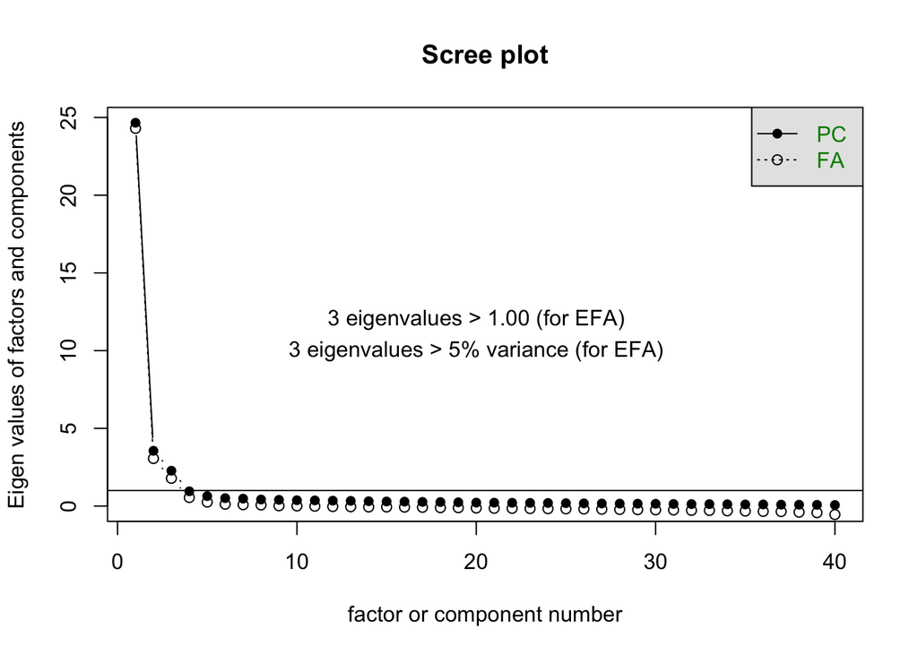

#### Step 2: Run EFA without rotation

```
## Factor Analysis using method =  minres
## Call: fa(r = d4_all, nfactors = 39, rotate = "none", fm = "minres",
##     cor = chosenCorType)
## Standardized loadings (pattern matrix) based upon correlation matrix
##                 MR1   MR2   MR4  MR10   MR3  MR12   MR6   MR7  MR15  MR14
## happy          0.92  0.19 -0.14 -0.02 -0.24  0.01 -0.04  0.04  0.01 -0.01
## depressed      0.76  0.33  0.06  0.12  0.04 -0.15 -0.02  0.02  0.20  0.16
## fear           0.92 -0.23  0.05 -0.01  0.10 -0.03 -0.19 -0.04  0.00 -0.01
## angry          0.86  0.13  0.06  0.04 -0.05 -0.10  0.00  0.04  0.07  0.10
## calm           0.89 -0.02  0.04  0.04 -0.04  0.08 -0.05 -0.02 -0.07  0.01
## sounds         0.68 -0.18  0.42 -0.28  0.05 -0.06  0.21  0.18 -0.14 -0.01
## seeing         0.77 -0.18  0.36 -0.20  0.04 -0.09  0.16  0.08 -0.08 -0.02
## temperature    0.62 -0.19  0.40 -0.19  0.08  0.02  0.12  0.18 -0.04  0.02
## odors          0.78 -0.11  0.29 -0.07  0.09 -0.04  0.09  0.07  0.03 -0.02
## depth          0.61  0.05  0.49  0.02  0.10  0.07  0.13  0.02  0.05  0.00
## computations   0.02  0.54  0.44 -0.07  0.10 -0.01  0.12  0.19 -0.06  0.03
## thoughts       0.82  0.16  0.11  0.14 -0.01  0.10  0.05  0.00 -0.01 -0.29
## reasoning      0.58  0.41  0.35  0.16  0.06  0.14  0.15  0.07  0.04 -0.14
## remembering    0.64  0.17  0.52 -0.04 -0.03 -0.03  0.15  0.13  0.18  0.02
## beliefs        0.54  0.59  0.05  0.21  0.20  0.15  0.05 -0.04 -0.19 -0.10
## hungry         0.88 -0.33 -0.11  0.01  0.17 -0.02  0.21 -0.10  0.00  0.00
## tired          0.94 -0.20 -0.01  0.01  0.00  0.00 -0.06  0.18 -0.01 -0.01
## pain           0.91 -0.29 -0.07  0.02  0.13  0.03 -0.01  0.07  0.01  0.00
## nauseated      0.84  0.08  0.02  0.01 -0.05 -0.01 -0.03 -0.02  0.09  0.10
## safe           0.88 -0.03  0.05  0.00 -0.03  0.18  0.00 -0.03 -0.04  0.10
## love           0.84  0.26 -0.07  0.11 -0.13 -0.05  0.00  0.03 -0.13  0.06
## recognizing    0.73  0.15  0.32 -0.15 -0.13 -0.17  0.12  0.21  0.02  0.03
## communicating  0.66  0.05  0.48 -0.08 -0.05  0.02  0.13  0.22  0.03  0.03
## guilt          0.65  0.61  0.00  0.14  0.21 -0.21  0.03  0.00  0.00 -0.06
## disrespected   0.63  0.51  0.07  0.15  0.23  0.02 -0.01  0.04 -0.11  0.24
## free_will      0.79  0.04  0.16  0.22  0.05  0.17  0.09 -0.07  0.02 -0.03
## choices        0.70  0.07  0.44  0.00  0.04  0.16  0.15  0.04  0.16 -0.01
## self_restraint 0.62  0.41  0.25  0.21  0.13  0.09  0.09  0.08  0.13  0.11
## intentions     0.75  0.15  0.24  0.09  0.11  0.22  0.07 -0.03  0.11 -0.03
## goal           0.56  0.16  0.40  0.07  0.10  0.24  0.15  0.02  0.17 -0.10
## conscious      0.82  0.00  0.11  0.09  0.02  0.07  0.06  0.00 -0.07 -0.15
## self_aware     0.69  0.27  0.17  0.21  0.09  0.18  0.12 -0.03 -0.02 -0.05
## desires        0.86  0.08  0.10  0.12 -0.04  0.10  0.01 -0.04  0.03 -0.01
## embarrassed    0.62  0.67 -0.08 -0.11  0.35  0.02 -0.04 -0.01  0.01  0.00
## emo_recog      0.67  0.45  0.16  0.13  0.07 -0.02  0.04  0.07 -0.05  0.12
```

[output cut: 231 more lines]

```
## Correlation of scores with factors             0.72  0.69 0.72 0.71  0.69
## Multiple R square of scores with factors       0.52  0.48 0.53 0.50  0.48
## Minimum correlation of possible factor scores  0.04 -0.04 0.05 0.00 -0.04
##                                                 MR31  MR32  MR33  MR34
## Correlation of scores with factors              0.65  0.63  0.61  0.55
## Multiple R square of scores with factors        0.42  0.39  0.37  0.31
## Minimum correlation of possible factor scores  -0.15 -0.21 -0.26 -0.39
##                                                 MR35  MR36  MR37  MR38
## Correlation of scores with factors              0.50  0.46  0.38  0.33
## Multiple R square of scores with factors        0.25  0.21  0.14  0.11
## Minimum correlation of possible factor scores  -0.49 -0.58 -0.72 -0.78
##                                                 MR39
## Correlation of scores with factors              0.18
## Multiple R square of scores with factors        0.03
## Minimum correlation of possible factor scores  -0.94
```

#### Step 3: Run EFA with oblimin rotation

```
## Factor Analysis using method =  minres
## Call: fa(r = d4_all, nfactors = nfactors_d4_all, rotate = "oblimin",
##     fm = "minres", cor = chosenCorType)
## Standardized loadings (pattern matrix) based upon correlation matrix
##                  MR2   MR1   MR3   h2   u2 com
## happy           0.45  0.62  0.03 0.84 0.16 1.8
## depressed       0.61  0.33  0.05 0.71 0.29 1.6
## fear            0.05  0.74  0.25 0.86 0.14 1.2
## angry           0.39  0.52  0.15 0.76 0.24 2.0
## calm            0.25  0.64  0.18 0.79 0.21 1.5
## sounds         -0.19  0.22  0.84 0.77 0.23 1.2
## seeing         -0.12  0.36  0.71 0.79 0.21 1.5
## temperature    -0.21  0.19  0.81 0.68 0.32 1.2
## odors           0.02  0.39  0.57 0.73 0.27 1.8
## depth           0.11  0.00  0.74 0.65 0.35 1.0
## computations    0.48 -0.72  0.48 0.58 0.42 2.6
## thoughts        0.42  0.42  0.19 0.72 0.28 2.4
## reasoning       0.59 -0.15  0.43 0.70 0.30 2.0
## remembering     0.22 -0.07  0.75 0.73 0.27 1.2
## beliefs         0.90 -0.05 -0.04 0.73 0.27 1.0
## hungry         -0.05  0.79  0.23 0.83 0.17 1.2
## tired           0.07  0.77  0.23 0.90 0.10 1.2
## pain           -0.01  0.81  0.21 0.88 0.12 1.1
## nauseated       0.33  0.58  0.10 0.72 0.28 1.7
## safe            0.21  0.61  0.23 0.78 0.22 1.5
## love            0.56  0.51 -0.03 0.78 0.22 2.0
## recognizing     0.22  0.17  0.57 0.68 0.32 1.5
## communicating   0.08  0.06  0.76 0.71 0.29 1.0
## guilt           0.89  0.08 -0.07 0.79 0.21 1.0
## disrespected    0.82  0.07  0.01 0.73 0.27 1.0
## free_will       0.31  0.41  0.28 0.67 0.33 2.7
## choices         0.17  0.09  0.69 0.72 0.28 1.2
## self_restraint  0.67 -0.04  0.28 0.69 0.31 1.3
## intentions      0.37  0.26  0.36 0.65 0.35 2.8
## goal            0.26 -0.05  0.59 0.55 0.45 1.4
## conscious       0.24  0.50  0.27 0.69 0.31 2.0
## self_aware      0.54  0.15  0.24 0.62 0.38 1.6
## desires         0.35  0.53  0.20 0.78 0.22 2.1
## embarrassed     0.90  0.07 -0.12 0.76 0.24 1.0
## emo_recog       0.71  0.07  0.16 0.71 0.29 1.1
```

[output cut: 25 more lines]

```
## The root mean square of the residuals (RMSR) is  0.02
## The df corrected root mean square of the residuals is  0.03
##
## The harmonic number of observations is  431 with the empirical chi square  412.62  with prob <  1
## The total number of observations was  431  with MLE Chi Square =  2246.7  with prob <  5.9e-171
##
## Tucker Lewis Index of factoring reliability =  0.91
## RMSEA index =  0.077  and the 90 % confidence intervals are  0.071 0.078
## BIC =  -1775.13
## Fit based upon off diagonal values = 1
## Measures of factor score adequacy
##                                                 MR2  MR1  MR3
## Correlation of scores with factors             0.98 0.99 0.98
## Multiple R square of scores with factors       0.97 0.97 0.95
## Minimum correlation of possible factor scores  0.94 0.94 0.91
```

back to TOC

##### Factor 1

Study 4, ALL conditions: Rotated Factor 1

|  | F1 |
| --- | --- |
| embarrassed | 0.9018816 |
| beliefs | 0.8968680 |
| guilt | 0.8901290 |
| morality | 0.8342636 |
| disrespected | 0.8198717 |
| pride | 0.7632293 |
| emo_recog | 0.7145727 |
| self_restraint | 0.6669838 |
| depressed | 0.6121355 |
| reasoning | 0.5933422 |
| love | 0.5649503 |
| self_aware | 0.5413943 |
| computations | 0.4784656 |
| joy | 0.4769566 |
| personality | 0.4679081 |
| happy | 0.4495767 |
| thoughts | 0.4249871 |
| angry | 0.3924566 |
| intentions | 0.3659627 |
| desires | 0.3514439 |
| nauseated | 0.3307287 |
| free_will | 0.3128684 |
| goal | 0.2580309 |
| calm | 0.2485633 |
| pleasure | 0.2461668 |
| conscious | 0.2420620 |
| recognizing | 0.2227127 |
| remembering | 0.2172967 |
| safe | 0.2117204 |
| choices | 0.1735503 |
| depth | 0.1122530 |
| communicating | 0.0848394 |
| tired | 0.0654121 |
| fear | 0.0517524 |
| odors | 0.0156964 |
| pain | -0.0058140 |
| hungry | -0.0451910 |
| seeing | -0.1164145 |
| sounds | -0.1932636 |
| temperature | -0.2062295 |

##### Factor 2

Study 4, ALL conditions: Rotated Factor 2

|  | F2 |
| --- | --- |
| pain | 0.8113911 |
| hungry | 0.7932834 |
| tired | 0.7738048 |
| fear | 0.7411343 |
| pleasure | 0.6615801 |
| calm | 0.6355742 |
| happy | 0.6169317 |
| safe | 0.6101309 |
| nauseated | 0.5822653 |
| joy | 0.5668870 |
| desires | 0.5272103 |
| angry | 0.5216222 |
| love | 0.5092261 |
| conscious | 0.4967620 |
| personality | 0.4557715 |
| thoughts | 0.4219388 |
| free_will | 0.4130935 |
| odors | 0.3894383 |
| seeing | 0.3558002 |
| depressed | 0.3294201 |
| intentions | 0.2595619 |
| sounds | 0.2187783 |
| pride | 0.2170787 |
| temperature | 0.1885972 |
| recognizing | 0.1714859 |
| self_aware | 0.1496946 |
| choices | 0.0868195 |
| guilt | 0.0836874 |
| embarrassed | 0.0746788 |
| disrespected | 0.0655174 |
| emo_recog | 0.0651278 |
| communicating | 0.0580091 |
| depth | -0.0010363 |
| self_restraint | -0.0422123 |
| goal | -0.0486536 |
| beliefs | -0.0511137 |
| remembering | -0.0672345 |
| morality | -0.1044385 |
| reasoning | -0.1545878 |
| computations | -0.7202885 |

##### Factor 3

Study 4, ALL conditions: Rotated Factor 3

|  | F3 |
| --- | --- |
| sounds | 0.8369067 |
| temperature | 0.8106029 |
| communicating | 0.7600327 |
| remembering | 0.7534883 |
| depth | 0.7368329 |
| seeing | 0.7106448 |
| choices | 0.6902574 |
| goal | 0.5918000 |
| recognizing | 0.5711083 |
| odors | 0.5695787 |
| computations | 0.4784963 |
| reasoning | 0.4331923 |
| intentions | 0.3611253 |
| self_restraint | 0.2784143 |
| free_will | 0.2781228 |
| conscious | 0.2670766 |
| fear | 0.2544704 |
| self_aware | 0.2415665 |
| hungry | 0.2290513 |
| safe | 0.2286487 |
| tired | 0.2265862 |
| pain | 0.2082285 |
| pleasure | 0.2039622 |
| desires | 0.1951531 |
| thoughts | 0.1913144 |
| calm | 0.1756957 |
| personality | 0.1693344 |
| emo_recog | 0.1572589 |
| angry | 0.1501175 |
| morality | 0.1108815 |
| nauseated | 0.1028601 |
| joy | 0.0555248 |
| depressed | 0.0520425 |
| happy | 0.0255363 |
| pride | 0.0076356 |
| disrespected | 0.0057781 |
| love | -0.0306122 |
| beliefs | -0.0419920 |
| guilt | -0.0698411 |
| embarrassed | -0.1159230 |

back to TOC

##### Plot!

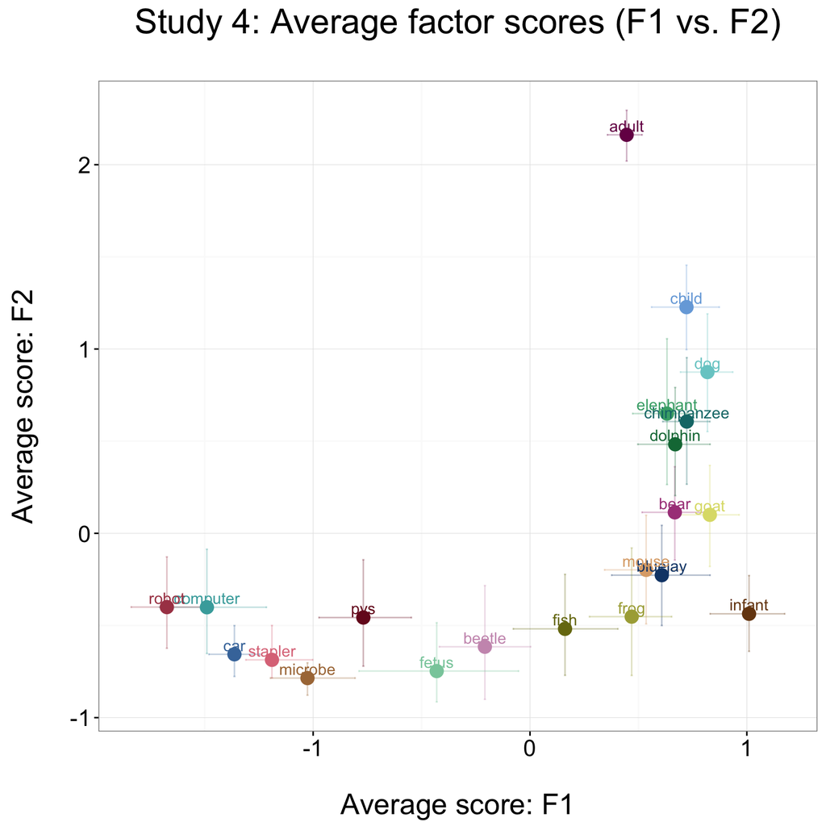

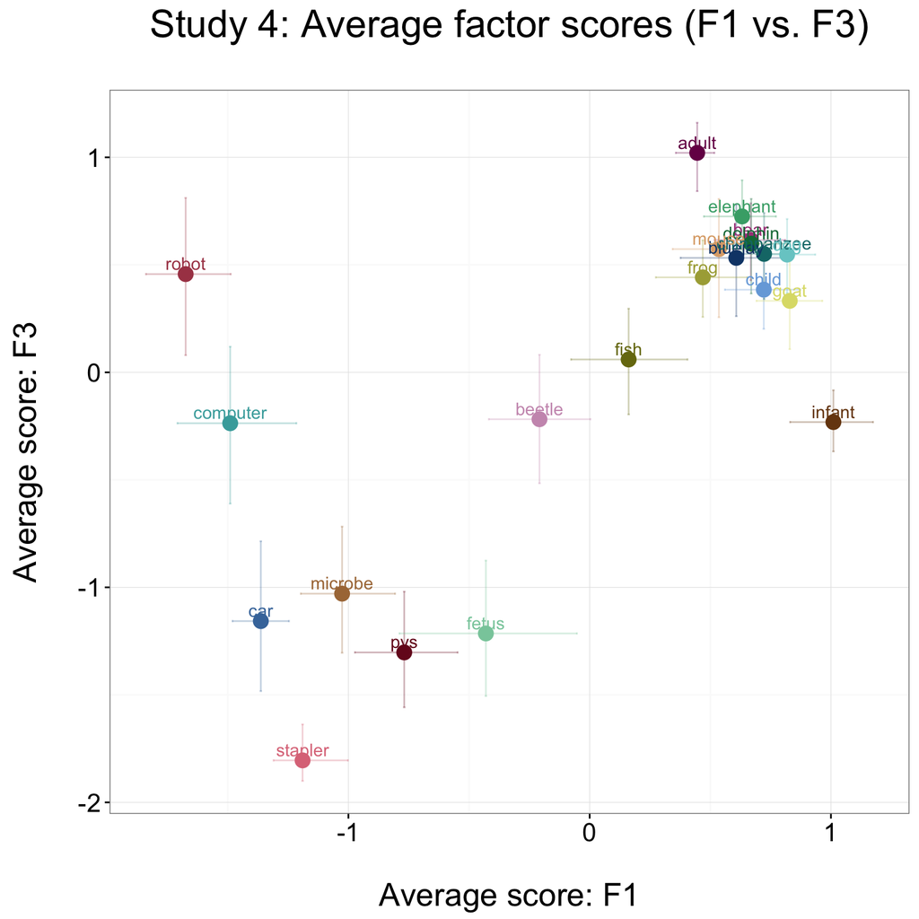

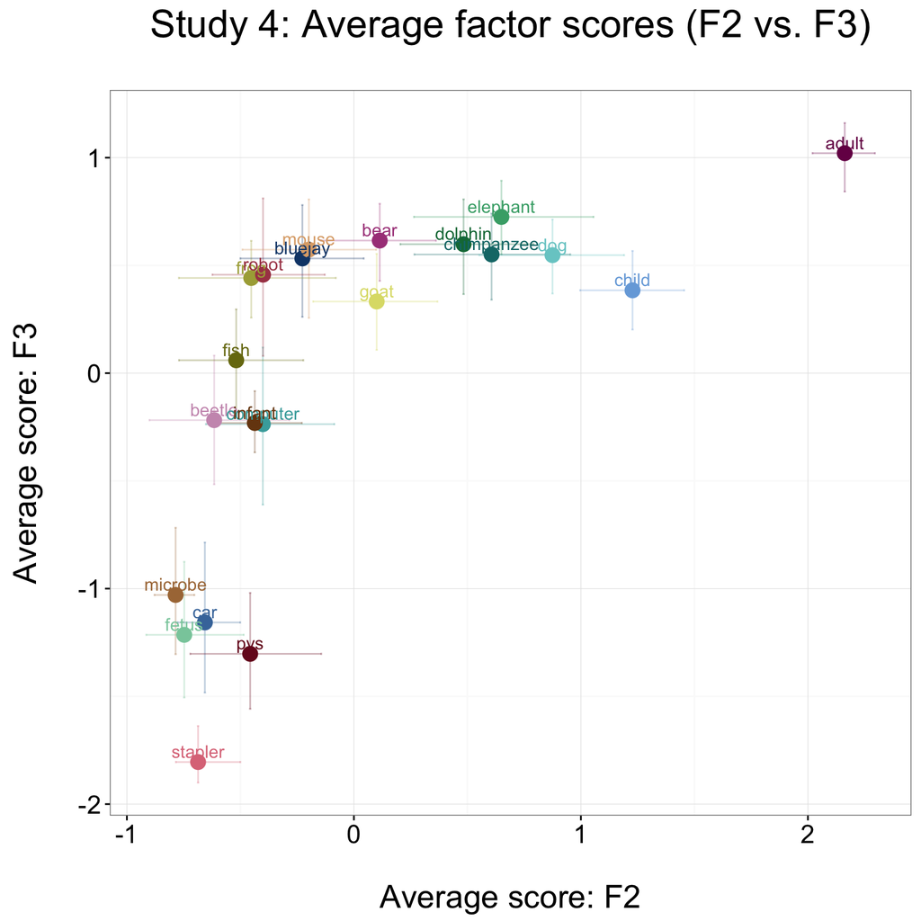

## Confirmatory factor analysis

### CFA: ALL conditions

#### ModelDD: Data-driven, three factors (MR1, MR2, MR3; see Study 1)

#### ModelWDM: Theoretical, three factors (SOCIAL-EMOTIONAL, BIOLOGICAL, PERCEPTUAL; see Weisman et al., 2015)

#### ModelGGW: Theoretical, two factors (AGENCY, EXPERIENCE; see Gray et al., 2007)

#### Compare models (not yet implemented)

```r
# MODELS HAVE DIFFERENT SETS OF VARIABLES, MIGHT NOT WORK
# # compare models (iff continuous and ML)
# customVuong(chosenDD = d4_all_fitDD,
#             chosenWDM = d4_all_fitWDM,
#             chosenGGW = d4_all_fitGGW)
```

back to TOC